# Exercícios métodos Computacionais

João Gilberto Nolêto Perna

2023-03-17

[figure not shown]

# **Exercise 1**

## 1.2. On the command line, type `demo(graphics)`. Follow prompts. You might prefer to re-size the windows.

```
##
##
##  demo(graphics)
##  ---- ~~~~~~~~
##
## > #  Copyright (C) 1997-2009 The R Core Team
## >
## > require(datasets)
##
## > require(grDevices); require(graphics)
##
## > ## Here is some code which illustrates some of the differences between
## > ## R and S graphics capabilities.  Note that colors are generally specified
## > ## by a character string name (taken from the X11 rgb.txt file) and that line
## > ## textures are given similarly.  The parameter "bg" sets the background
## > ## parameter for the plot and there is also an "fg" parameter which sets
## > ## the foreground color.
## >
## >
## > x <- stats::rnorm(50)
##
## > opar <- par(bg = "white")
##
## > plot(x, ann = FALSE, type = "n")
```

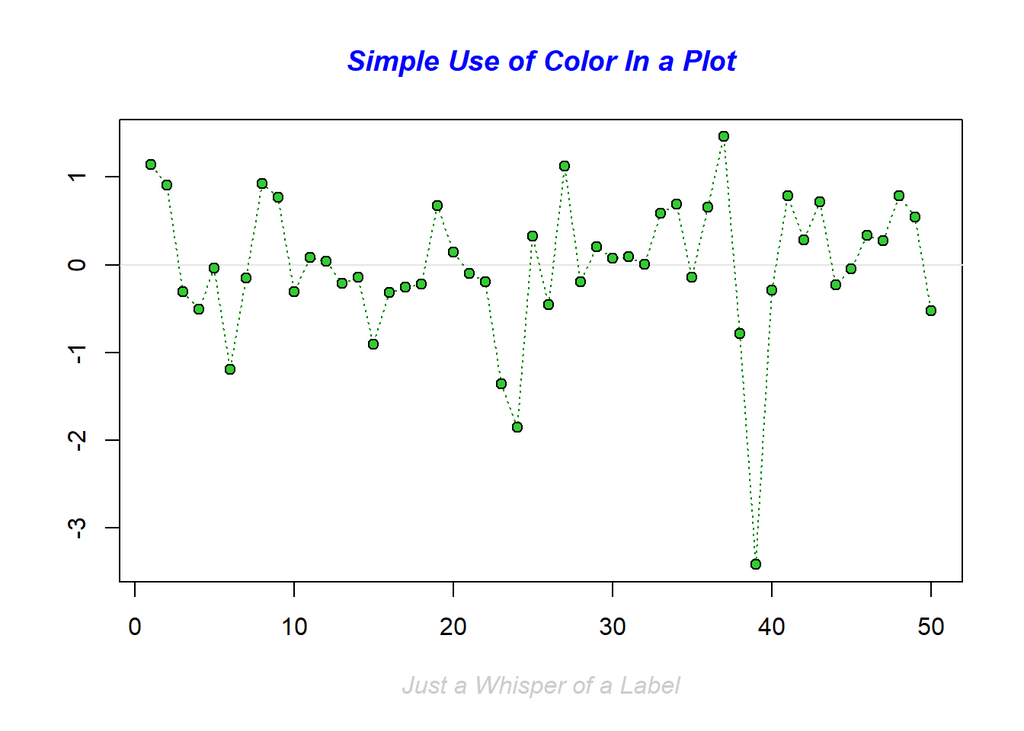

```
##
## > abline(h = 0, col = gray(.90))
##
## > lines(x, col = "green4", lty = "dotted")
##
## > points(x, bg = "limegreen", pch = 21)
##
## > title(main = "Simple Use of Color In a Plot",
## +       xlab = "Just a Whisper of a Label",
## +       col.main = "blue", col.lab = gray(.8),
## +       cex.main = 1.2, cex.lab = 1.0, font.main = 4, font.lab = 3)
##
## > ## A little color wheel.    This code just plots equally spaced hues in
## > ## a pie chart.    If you have a cheap SVGA monitor (like me) you will
## > ## probably find that numerically equispaced does not mean visually
## > ## equispaced.  On my display at home, these colors tend to cluster at
## > ## the RGB primaries.  On the other hand on the SGI Indy at work the
## > ## effect is near perfect.
## >
## > par(bg = "gray")
##
## > pie(rep(1,24), col = rainbow(24), radius = 0.9)
```

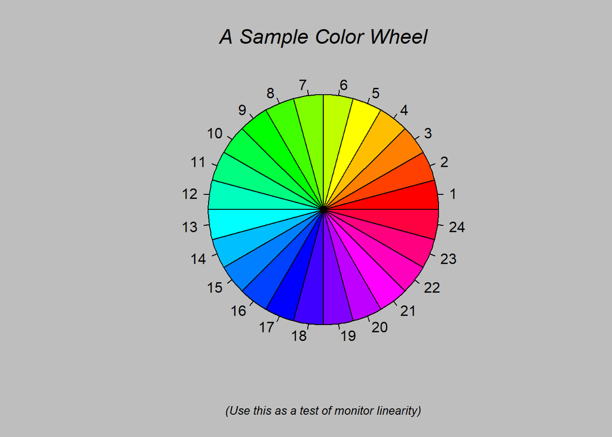

```
##
## > title(main = "A Sample Color Wheel", cex.main = 1.4, font.main = 3)
##
## > title(xlab = "(Use this as a test of monitor linearity)",
## +       cex.lab = 0.8, font.lab = 3)
##
## > ## We have already confessed to having these.  This is just showing off X11
## > ## color names (and the example (from the postscript manual) is pretty "cute".
## >
## > pie.sales <- c(0.12, 0.3, 0.26, 0.16, 0.04, 0.12)
##
## > names(pie.sales) <- c("Blueberry", "Cherry",
## +              "Apple", "Boston Cream", "Other", "Vanilla Cream")
##
## > pie(pie.sales,
## +     col = c("purple","violetred1","green3","cornsilk","cyan","white"))
```

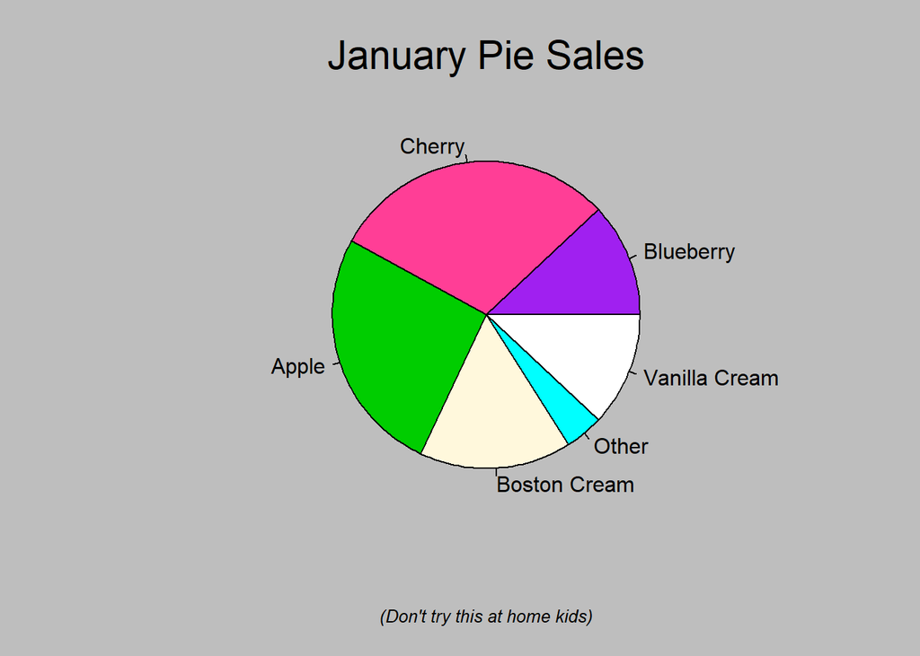

```
##
## > title(main = "January Pie Sales", cex.main = 1.8, font.main = 1)
##
## > title(xlab = "(Don't try this at home kids)", cex.lab = 0.8, font.lab = 3)
##
## > ## Boxplots:  I couldn't resist the capability for filling the "box".
## > ## The use of color seems like a useful addition, it focuses attention
## > ## on the central bulk of the data.
## >
## > par(bg="cornsilk")
##
## > n <- 10
##
## > g <- gl(n, 100, n*100)
##
## > x <- rnorm(n*100) + sqrt(as.numeric(g))
##
## > boxplot(split(x,g), col="lavender", notch=TRUE)
```

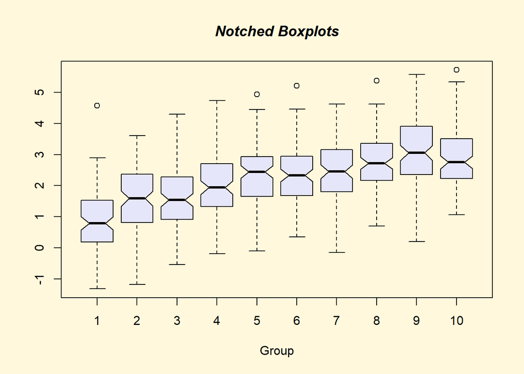

```
##
## > title(main="Notched Boxplots", xlab="Group", font.main=4, font.lab=1)
##
## > ## An example showing how to fill between curves.
## >
## > par(bg="white")
##
## > n <- 100
##
## > x <- c(0,cumsum(rnorm(n)))
##
## > y <- c(0,cumsum(rnorm(n)))
##
## > xx <- c(0:n, n:0)
##
## > yy <- c(x, rev(y))
##
## > plot(xx, yy, type="n", xlab="Time", ylab="Distance")
```

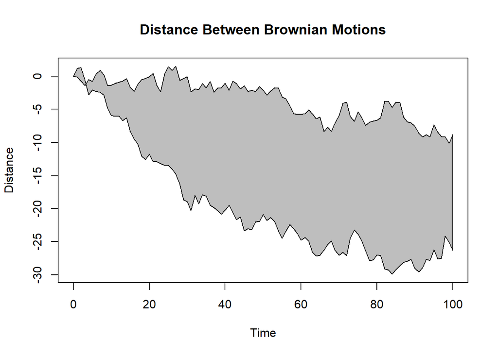

```
##
## > polygon(xx, yy, col="gray")
##
## > title("Distance Between Brownian Motions")
##
## > ## Colored plot margins, axis labels and titles.    You do need to be
## > ## careful with these kinds of effects.    It's easy to go completely
## > ## over the top and you can end up with your lunch all over the keyboard.
## > ## On the other hand, my market research clients love it.
## >
## > x <- c(0.00, 0.40, 0.86, 0.85, 0.69, 0.48, 0.54, 1.09, 1.11, 1.73, 2.05, 2.02)
##
## > par(bg="lightgray")
##
## > plot(x, type="n", axes=FALSE, ann=FALSE)
```

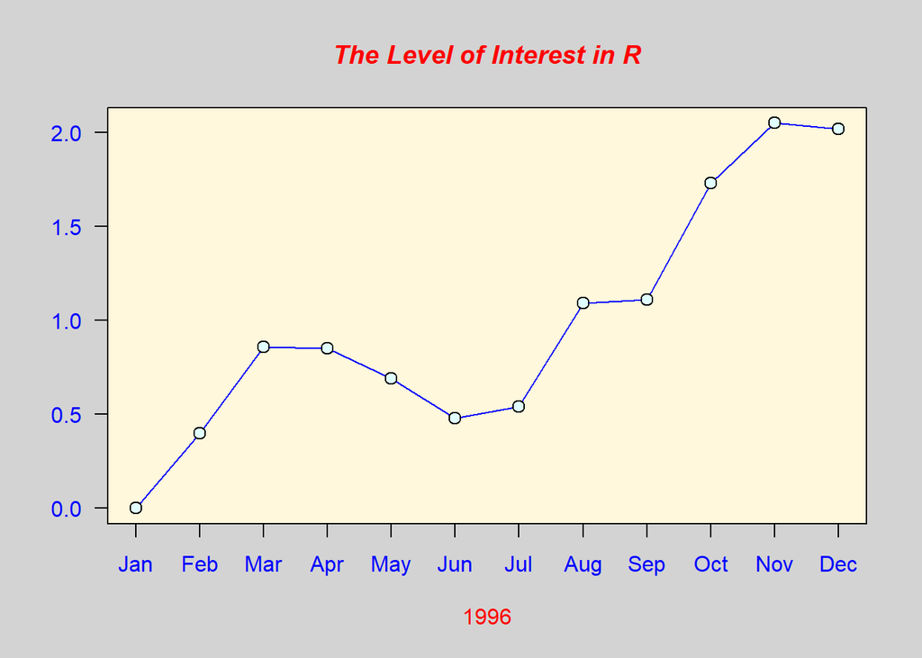

```
##
## > usr <- par("usr")
##
## > rect(usr[1], usr[3], usr[2], usr[4], col="cornsilk", border="black")
##
## > lines(x, col="blue")
##
## > points(x, pch=21, bg="lightcyan", cex=1.25)
##
## > axis(2, col.axis="blue", las=1)
##
## > axis(1, at=1:12, lab=month.abb, col.axis="blue")
##
## > box()
##
## > title(main= "The Level of Interest in R", font.main=4, col.main="red")
##
## > title(xlab= "1996", col.lab="red")
##
## > ## A filled histogram, showing how to change the font used for the
## > ## main title without changing the other annotation.
## >
## > par(bg="cornsilk")
##
## > x <- rnorm(1000)
##
## > hist(x, xlim=range(-4, 4, x), col="lavender", main="")
```

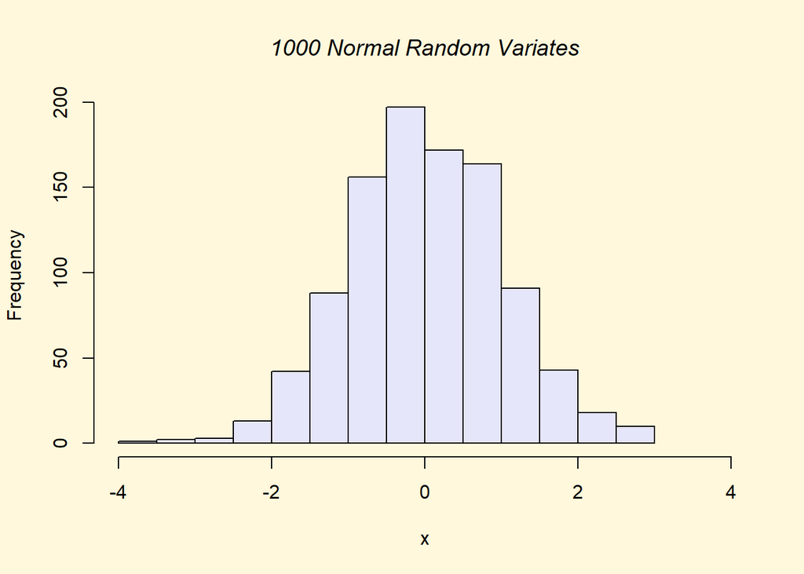

```
##
## > title(main="1000 Normal Random Variates", font.main=3)
##
## > ## A scatterplot matrix
## > ## The good old Iris data (yet again)
## >
## > pairs(iris[1:4], main="Edgar Anderson's Iris Data", font.main=4, pch=19)
```

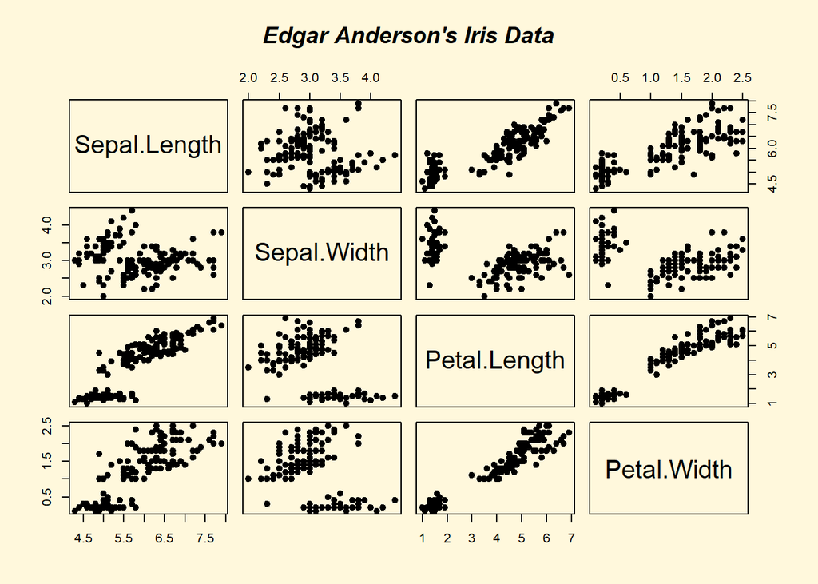

```
##
## > pairs(iris[1:4], main="Edgar Anderson's Iris Data", pch=21,
## +       bg = c("red", "green3", "blue")[unclass(iris$Species)])
```

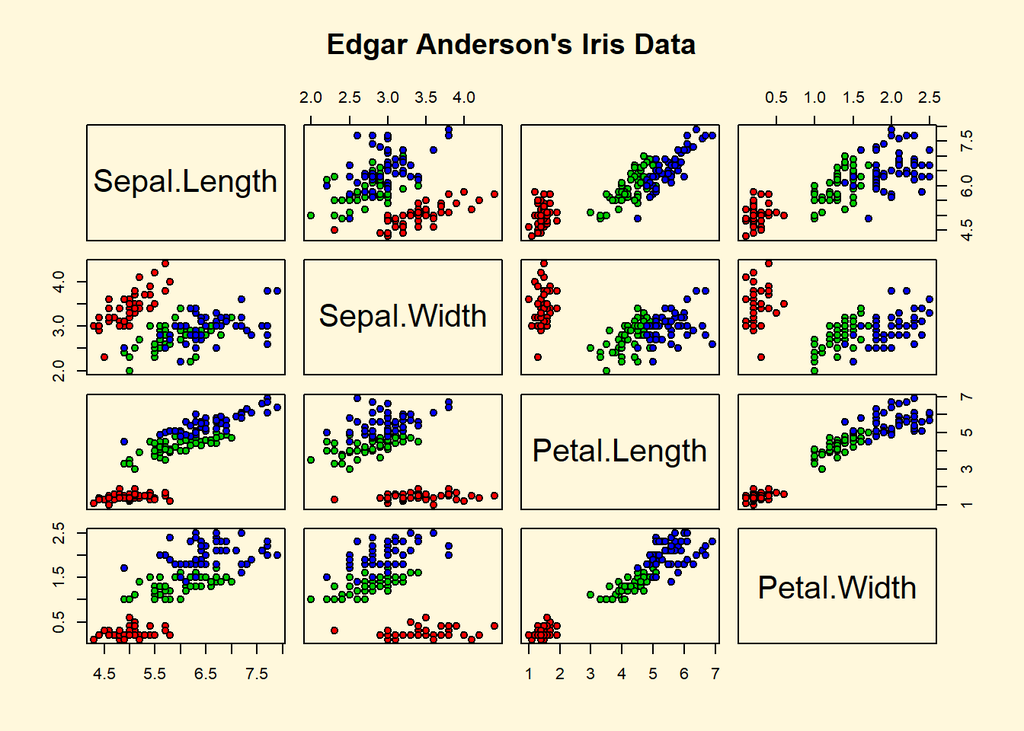

```
##
## > ## Contour plotting
## > ## This produces a topographic map of one of Auckland's many volcanic "peaks".
## >
## > x <- 10*1:nrow(volcano)
##
## > y <- 10*1:ncol(volcano)
##
## > lev <- pretty(range(volcano), 10)
##
## > par(bg = "lightcyan")
##
## > pin <- par("pin")
##
## > xdelta <- diff(range(x))
##
## > ydelta <- diff(range(y))
##
## > xscale <- pin[1]/xdelta
##
## > yscale <- pin[2]/ydelta
##
## > scale <- min(xscale, yscale)
##
## > xadd <- 0.5*(pin[1]/scale - xdelta)
##
## > yadd <- 0.5*(pin[2]/scale - ydelta)
##
## > plot(numeric(0), numeric(0),
## +      xlim = range(x)+c(-1,1)*xadd, ylim = range(y)+c(-1,1)*yadd,
## +      type = "n", ann = FALSE)
```

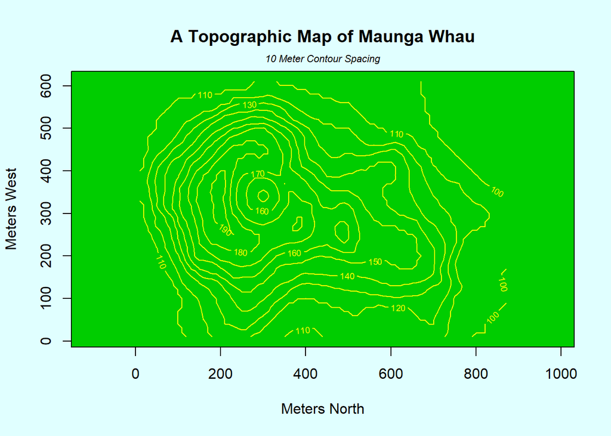

```
##
## > usr <- par("usr")
##
## > rect(usr[1], usr[3], usr[2], usr[4], col="green3")
##
## > contour(x, y, volcano, levels = lev, col="yellow", lty="solid", add=TRUE)
##
## > box()
##
## > title("A Topographic Map of Maunga Whau", font= 4)
##
## > title(xlab = "Meters North", ylab = "Meters West", font= 3)
##
## > mtext("10 Meter Contour Spacing", side=3, line=0.35, outer=FALSE,
## +       at = mean(par("usr")[1:2]), cex=0.7, font=3)
##
## > ## Conditioning plots
## >
## > par(bg="cornsilk")
##
## > coplot(lat ~ long | depth, data = quakes, pch = 21, bg = "green3")
```

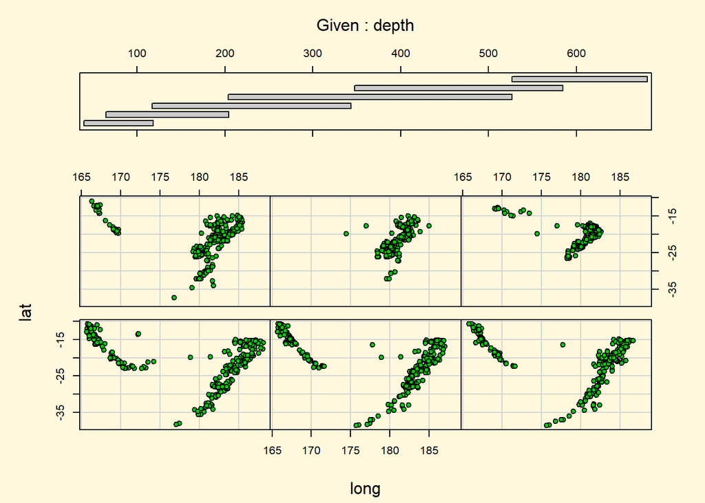

```
##
## > par(opar)
```

```r
demo(graphics)
```

## 3. On the command line, type demo(image). This demonstration is concerned with representations of 3D data. demo(image)

## 4. Get help on the function q, by typing `?q`

```r
?q
```

## 5. Quit R , by typing `q()`.

> q()

# **Exercise 2**

## 2.0 Baixar o arquivo

```r
url <- "<https://www.ma.imperial.ac.uk/~das01/RCourse/hills.txt>"
download.file(url, "hills.txt")
```

## 2.1. Read the file, assigning the result to the object hills

```r
hills <- read.table("hills.txt")
```

## 2.2. Examine the object. Note column and row names hills

```r
hills
```

```
##                  dist climb    time
## Greenmantle       2.5   650  16.083
## Carnethy          6.0  2500  48.350
## Craig Dunain      6.0   900  33.650
## Ben Rha           7.5   800  45.600
## Ben Lomond        8.0  3070  62.267
## Goatfell          8.0  2866  73.217
## Bens of Jura     16.0  7500 204.617
## Cairnpapple       6.0   800  36.367
## Scolty            5.0   800  29.750
## Traprain          6.0   650  39.750
## Lairig Ghru      28.0  2100 192.667
## Dollar            5.0  2000  43.050
## Lomonds           9.5  2200  65.000
## Cairn Table       6.0   500  44.133
## Eildon Two        4.5  1500  26.933
## Cairngorm        10.0  3000  72.250
## Seven Hills      14.0  2200  98.417
## Knock Hill        3.0   350  78.650
## Black Hill        4.5  1000  17.417
## Creag Beag        5.5   600  32.567
## Kildcon Hill      3.0   300  15.950
## Meall Ant-Suidhe  3.5  1500  27.900
## Half Ben Nevis    6.0  2200  47.633
## Cow Hill          2.0   900  17.933
## N Berwick Law     3.0   600  18.683
## Creag Dubh        4.0  2000  26.217
## Burnswark         6.0   800  34.433
## Largo Law         5.0   950  28.567
## Criffel           6.5  1750  50.500
## Acmony            5.0   500  20.950
## Ben Nevis        10.0  4400  85.583
## Knockfarrel       6.0   600  32.383
## Two Breweries    18.0  5200 170.250
## Cockleroi         4.5   850  28.100
## Moffat Chase     20.0  5000 159.833
```

## 2.3. Construct a scatterplot matrix

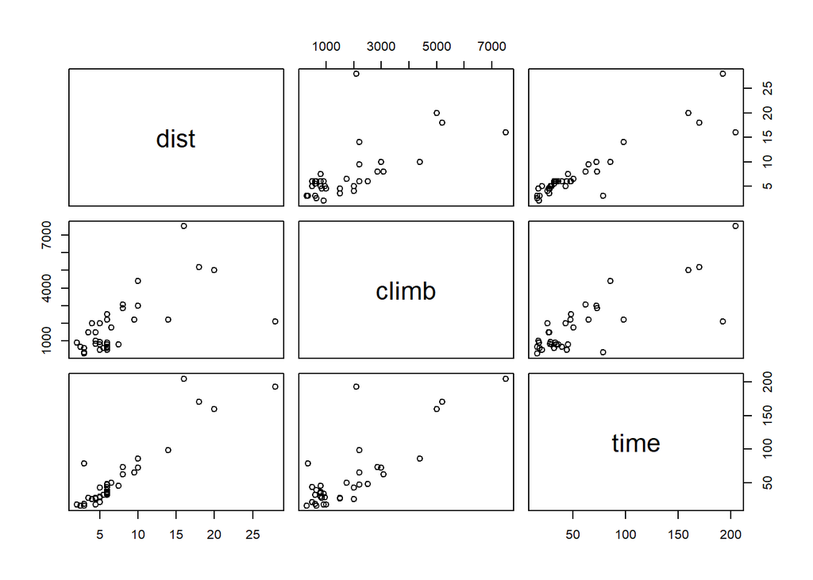

```r
pairs(hills)
```

## 2.4. Make the columns of the hills object available by name

```r
attach(hills)
```

## 2.5. Construct a scatter plot. The function call in this way means the first argument is the horizontal axis

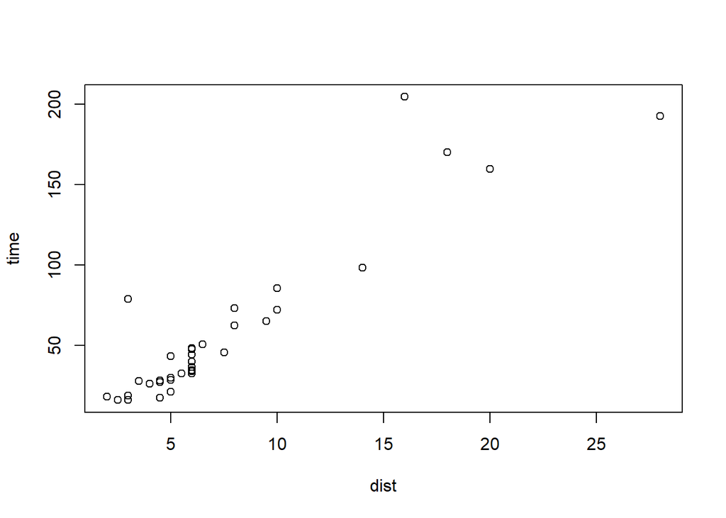

```r
plot(dist,time)
```

## 2.6. Interact with the plot to label points - right click to finish

> identify(dist,time,row.names(hills))

## 2.7. Compute a linear regression of time against distance

```r
lm(time ~ dist)
```

```
##
## Call:
## lm(formula = time ~ dist)
##
## Coefficients:
## (Intercept)         dist
##      -4.841        8.330
```

## 2.8. Obtain more information about the regression

```r
summary(lm(time ~ dist))
```

```
##
## Call:
## lm(formula = time ~ dist)
##
## Residuals:
##     Min      1Q  Median      3Q     Max
## -35.745  -9.037  -4.201   2.849  76.170
##
## Coefficients:
##             Estimate Std. Error t value Pr(>|t|)
## (Intercept)  -4.8407     5.7562  -0.841    0.406
## dist          8.3305     0.6196  13.446 6.08e-15 ***
## ---
## Signif. codes:  0 '***' 0.001 '**' 0.01 '*' 0.05 '.' 0.1 ' ' 1
##
## Residual standard error: 19.96 on 33 degrees of freedom
## Multiple R-squared:  0.8456, Adjusted R-squared:  0.841
## F-statistic: 180.8 on 1 and 33 DF,  p-value: 6.084e-15
```

## 2.9. Add the least squares regression line - note anonymous function call

```r
abline(lm(time~dist))
```

## 2.10. Obtain some diagnostics plots - note the different arguments to the plot function. Be aware of the prompt in the Console.

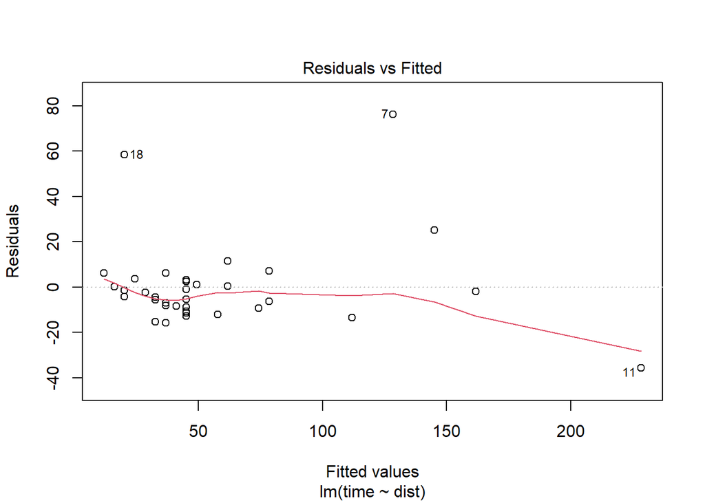

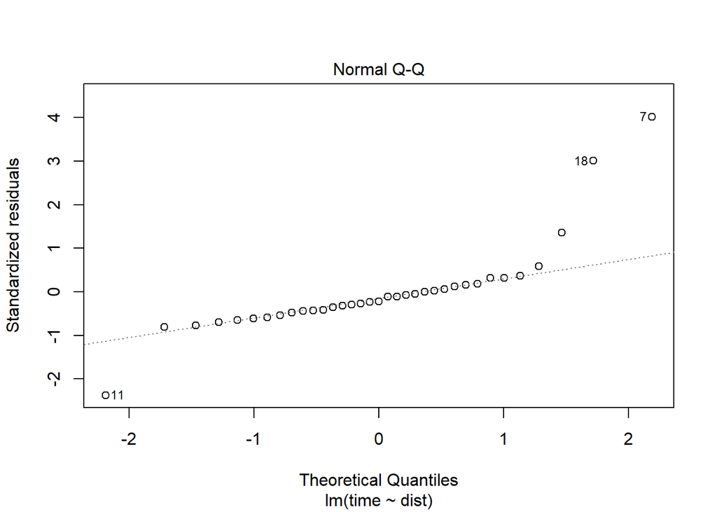

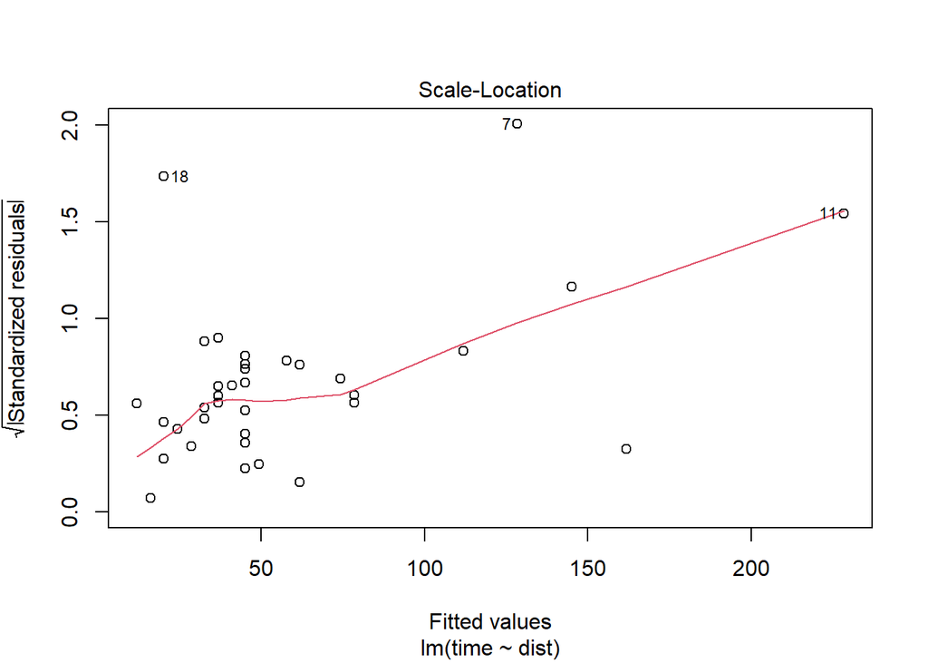

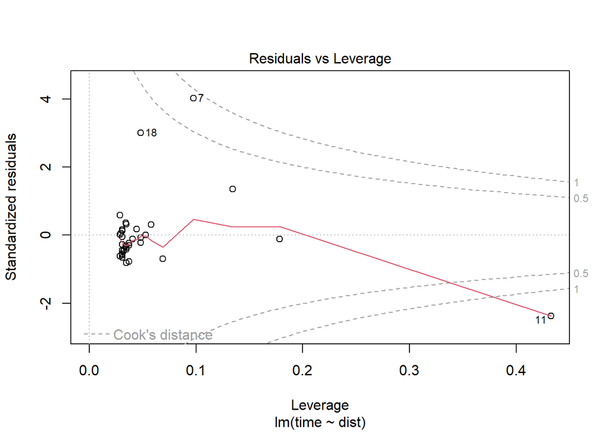

```r
plot(lm(time ~ dist))
```

## 2.11. there are many pre-defined system objects. Display the value of pi - note that this is a reserved word

```r
pi
```

```
## [1] 3.141593
```

## 2.12. List objects in current working space ls() #2.13. Display the object ls

```r
ls
```

```
## function (name, pos = -1L, envir = as.environment(pos), all.names = FALSE,
##     pattern, sorted = TRUE)
## {
##     if (!missing(name)) {
##         pos <- tryCatch(name, error = function(e) e)
##         if (inherits(pos, "error")) {
##             name <- substitute(name)
##             if (!is.character(name))
##                 name <- deparse(name)
##             warning(gettextf("%s converted to character string",
##                 sQuote(name)), domain = NA)
##             pos <- name
##         }
##     }
##     all.names <- .Internal(ls(envir, all.names, sorted))
##     if (!missing(pattern)) {
##         if ((ll <- length(grep("[", pattern, fixed = TRUE))) &&
##             ll != length(grep("]", pattern, fixed = TRUE))) {
##             if (pattern == "[") {
##                 pattern <- "\\["
##                 warning("replaced regular expression pattern '[' by  '\\\\['")
##             }
##             else if (length(grep("[^\\\\]\\[<-", pattern))) {
##                 pattern <- sub("\\[<-", "\\\\\\[<-", pattern)
##                 warning("replaced '[<-' by '\\\\[<-' in regular expression pattern")
##             }
##         }
##         grep(pattern, all.names, value = TRUE)
##     }
##     else all.names
## }
## <bytecode: 0x0000029f1dda72c0>
## <environment: namespace:base>
```

## 2.14. Create a copy of the hills object

```r
hill.cp <- hills
```

## 2.15. List objects in current working space

```r
ls()
```

```
##  [1] "g"         "hill.cp"   "hills"     "lev"       "n"         "opar"
##  [7] "pie.sales" "pin"       "scale"     "usr"       "x"         "xadd"
## [13] "xdelta"    "xscale"    "xx"        "y"         "yadd"      "ydelta"
## [19] "yscale"    "yy"
```

## 2.16. Delete the copy. Note that there is no undelete functionality. rm(hill.cp)

```r
rm(hill.cp)
```

# Exercise 3

```r
coeffs <- sample(-20:20,3,replace=T)
```

## 3.2. Determine the class of the object coeffs.

```r
class(coeffs)
```

```
## [1] "integer"
```

## 3.3. Determine the length of the object coeffs

```r
length(coeffs)
```

```
## [1] 3
```

## 3.4. Determine the names associated with the vector

```r
names(coeffs)
```

## 3.5. Assign some names. Note the function call occurring on the right hand of the assignment operator.

```r
names(coeffs) <- c("a","b","c")
```

## 3.6. Prepare to plot the equation, by constructing a regularly spaced vector for the horizontal axis

```r
x <- seq(-3,3,length=200)
x
```

```
##   [1] -3.00000000 -2.96984925 -2.93969849 -2.90954774 -2.87939698 -2.84924623
##   [7] -2.81909548 -2.78894472 -2.75879397 -2.72864322 -2.69849246 -2.66834171
##  [13] -2.63819095 -2.60804020 -2.57788945 -2.54773869 -2.51758794 -2.48743719
##  [19] -2.45728643 -2.42713568 -2.39698492 -2.36683417 -2.33668342 -2.30653266
##  [25] -2.27638191 -2.24623116 -2.21608040 -2.18592965 -2.15577889 -2.12562814
##  [31] -2.09547739 -2.06532663 -2.03517588 -2.00502513 -1.97487437 -1.94472362
##  [37] -1.91457286 -1.88442211 -1.85427136 -1.82412060 -1.79396985 -1.76381910
##  [43] -1.73366834 -1.70351759 -1.67336683 -1.64321608 -1.61306533 -1.58291457
##  [49] -1.55276382 -1.52261307 -1.49246231 -1.46231156 -1.43216080 -1.40201005
##  [55] -1.37185930 -1.34170854 -1.31155779 -1.28140704 -1.25125628 -1.22110553
##  [61] -1.19095477 -1.16080402 -1.13065327 -1.10050251 -1.07035176 -1.04020101
##  [67] -1.01005025 -0.97989950 -0.94974874 -0.91959799 -0.88944724 -0.85929648
##  [73] -0.82914573 -0.79899497 -0.76884422 -0.73869347 -0.70854271 -0.67839196
##  [79] -0.64824121 -0.61809045 -0.58793970 -0.55778894 -0.52763819 -0.49748744
##  [85] -0.46733668 -0.43718593 -0.40703518 -0.37688442 -0.34673367 -0.31658291
```

[output cut: 19 more lines]

## 3.7. Evaluate the quadratic at each point in vector x

```r
y <- coeffs[1]*x^2+coeffs[2]*x+coeffs[3]
y
```

```
##   [1]  46.00000000  45.21880761  44.44306962  43.67278604  42.90795687
##   [6]  42.14858211  41.39466175  40.64619580  39.90318426  39.16562713
##  [11]  38.43352441  37.70687609  36.98568218  36.26994268  35.55965758
##  [16]  34.85482690  34.15545062  33.46152875  32.77306129  32.09004823
##  [21]  31.41248958  30.74038534  30.07373551  29.41254009  28.75679907
##  [26]  28.10651246  27.46168026  26.82230247  26.18837908  25.55991010
##  [31]  24.93689553  24.31933537  23.70722962  23.10057827  22.49938133
##  [36]  21.90363880  21.31335067  20.72851696  20.14913765  19.57521275
##  [41]  19.00674225  18.44372617  17.88616449  17.33405722  16.78740436
##  [46]  16.24620590  15.71046186  15.18017222  14.65533699  14.13595616
##  [51]  13.62202975  13.11355774  12.61054014  12.11297695  11.62086816
##  [56]  11.13421378  10.65301381  10.17726825   9.70697710   9.24214035
##  [61]   8.78275801   8.32883008   7.88035656   7.43733744   6.99977273
##  [66]   6.56766243   6.14100654   5.71980506   5.30405798   4.89376531
##  [71]   4.48892705   4.08954319   3.69561375   3.30713871   2.92411808
```

[output cut: 25 more lines]

## 3.8. Construct the plot

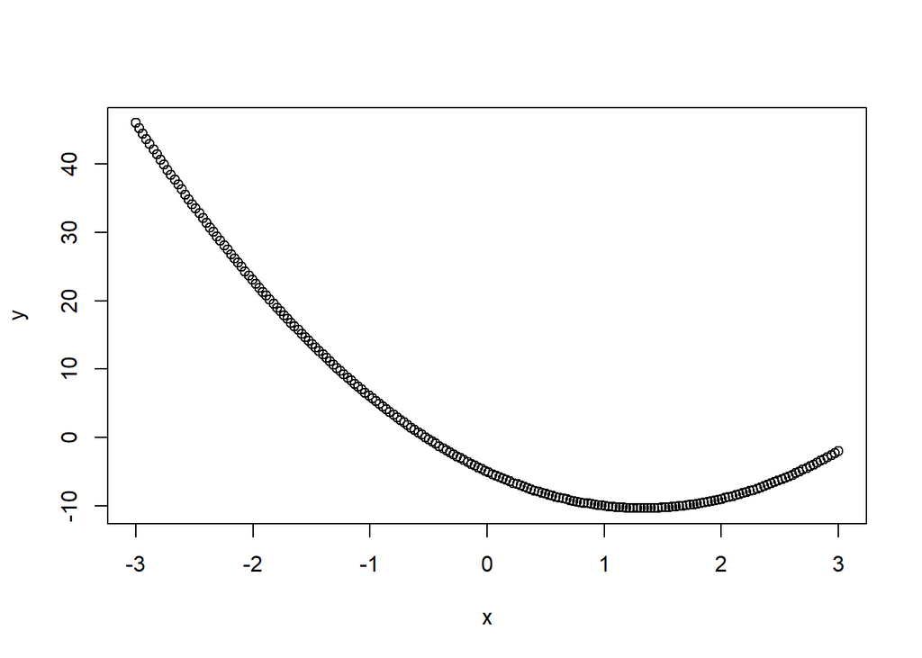

```r
plot(x,y)
plot(y=y,x=x)
```

## 3.9. Does the equation have real roots? Compute the discriminant

```r
coeffs[2]^2-4*coeffs[1]*coeffs[3]
```

```
##   b
## 124
```

```r
coeffs
```

```
##  a  b  c
##  3 -8 -5
```

## 3.10. Oops, we didn’t retain the value! R stores the last unassigned object in the system object.Last.value

```r
disc <- .Last.value
```

## 3.11. Create a vector of type character, and display the second elemen

```r
chr.vec <- sample(letters,5); chr.vec[2]
```

```
## [1] "r"
```

# 3.Problems

## 3.1*. Compute the real roots of the quadratic equation

### Criando uma função para resolução

```r
Bhaskara <- function(a,b,c){
  if(a == 0)
    print("A equação não é do segundo grau")
  else{
    delta = (b*b)-(4*a*c)
  if(delta<0)
    print("Não existe raiz real")
  if(delta>0){
    print("Existem duas raizes reais e diferentes")
    x1 = (-b+sqrt(delta))/(2*a)
    x2 = (-b-sqrt(delta))/(2*a)
    return(c(x1,x2))}
  if(delta == 0){
    print("Existem duas raizes reais e iguais")
    x1 = (-b+sqrt(delta))/(2*a)
    return(x1)}}}
Bhaskara(6,7,8)
```

```
## [1] "Não existe raiz real"
```

## 3.2* Without using R , determine the result of the following computation

```r
x <- c(1,2,3)
x[1]/x[2]^3-1+2*x[3]-x[2-1]
```

```
## [1] 4.125
```

# Exercise 4

## 4.1. Create a logical vector

```r
x <- seq(-3,3,length=200) > 0
x
```

```
##   [1] FALSE FALSE FALSE FALSE FALSE FALSE FALSE FALSE FALSE FALSE FALSE FALSE
##  [13] FALSE FALSE FALSE FALSE FALSE FALSE FALSE FALSE FALSE FALSE FALSE FALSE
##  [25] FALSE FALSE FALSE FALSE FALSE FALSE FALSE FALSE FALSE FALSE FALSE FALSE
##  [37] FALSE FALSE FALSE FALSE FALSE FALSE FALSE FALSE FALSE FALSE FALSE FALSE
##  [49] FALSE FALSE FALSE FALSE FALSE FALSE FALSE FALSE FALSE FALSE FALSE FALSE
##  [61] FALSE FALSE FALSE FALSE FALSE FALSE FALSE FALSE FALSE FALSE FALSE FALSE
##  [73] FALSE FALSE FALSE FALSE FALSE FALSE FALSE FALSE FALSE FALSE FALSE FALSE
##  [85] FALSE FALSE FALSE FALSE FALSE FALSE FALSE FALSE FALSE FALSE FALSE FALSE
##  [97] FALSE FALSE FALSE FALSE  TRUE  TRUE  TRUE  TRUE  TRUE  TRUE  TRUE  TRUE
## [109]  TRUE  TRUE  TRUE  TRUE  TRUE  TRUE  TRUE  TRUE  TRUE  TRUE  TRUE  TRUE
## [121]  TRUE  TRUE  TRUE  TRUE  TRUE  TRUE  TRUE  TRUE  TRUE  TRUE  TRUE  TRUE
## [133]  TRUE  TRUE  TRUE  TRUE  TRUE  TRUE  TRUE  TRUE  TRUE  TRUE  TRUE  TRUE
## [145]  TRUE  TRUE  TRUE  TRUE  TRUE  TRUE  TRUE  TRUE  TRUE  TRUE  TRUE  TRUE
## [157]  TRUE  TRUE  TRUE  TRUE  TRUE  TRUE  TRUE  TRUE  TRUE  TRUE  TRUE  TRUE
## [169]  TRUE  TRUE  TRUE  TRUE  TRUE  TRUE  TRUE  TRUE  TRUE  TRUE  TRUE  TRUE
## [181]  TRUE  TRUE  TRUE  TRUE  TRUE  TRUE  TRUE  TRUE  TRUE  TRUE  TRUE  TRUE
## [193]  TRUE  TRUE  TRUE  TRUE  TRUE  TRUE  TRUE  TRUE
```

## 4.2. negate this vector

```r
!x
```

```
##   [1]  TRUE  TRUE  TRUE  TRUE  TRUE  TRUE  TRUE  TRUE  TRUE  TRUE  TRUE  TRUE
##  [13]  TRUE  TRUE  TRUE  TRUE  TRUE  TRUE  TRUE  TRUE  TRUE  TRUE  TRUE  TRUE
##  [25]  TRUE  TRUE  TRUE  TRUE  TRUE  TRUE  TRUE  TRUE  TRUE  TRUE  TRUE  TRUE
##  [37]  TRUE  TRUE  TRUE  TRUE  TRUE  TRUE  TRUE  TRUE  TRUE  TRUE  TRUE  TRUE
##  [49]  TRUE  TRUE  TRUE  TRUE  TRUE  TRUE  TRUE  TRUE  TRUE  TRUE  TRUE  TRUE
##  [61]  TRUE  TRUE  TRUE  TRUE  TRUE  TRUE  TRUE  TRUE  TRUE  TRUE  TRUE  TRUE
##  [73]  TRUE  TRUE  TRUE  TRUE  TRUE  TRUE  TRUE  TRUE  TRUE  TRUE  TRUE  TRUE
##  [85]  TRUE  TRUE  TRUE  TRUE  TRUE  TRUE  TRUE  TRUE  TRUE  TRUE  TRUE  TRUE
##  [97]  TRUE  TRUE  TRUE  TRUE FALSE FALSE FALSE FALSE FALSE FALSE FALSE FALSE
## [109] FALSE FALSE FALSE FALSE FALSE FALSE FALSE FALSE FALSE FALSE FALSE FALSE
## [121] FALSE FALSE FALSE FALSE FALSE FALSE FALSE FALSE FALSE FALSE FALSE FALSE
## [133] FALSE FALSE FALSE FALSE FALSE FALSE FALSE FALSE FALSE FALSE FALSE FALSE
## [145] FALSE FALSE FALSE FALSE FALSE FALSE FALSE FALSE FALSE FALSE FALSE FALSE
## [157] FALSE FALSE FALSE FALSE FALSE FALSE FALSE FALSE FALSE FALSE FALSE FALSE
## [169] FALSE FALSE FALSE FALSE FALSE FALSE FALSE FALSE FALSE FALSE FALSE FALSE
## [181] FALSE FALSE FALSE FALSE FALSE FALSE FALSE FALSE FALSE FALSE FALSE FALSE
## [193] FALSE FALSE FALSE FALSE FALSE FALSE FALSE FALSE
```

## 4.3. Compute the truth table for logical AND

```r
c(T,T,F,F) & c(T,F,F,T)
```

```
## [1]  TRUE FALSE FALSE FALSE
```

## 4.4. Explore arithmetic with logical and numeric

```r
1:3 + c(T,F,T)
```

```
## [1] 2 2 4
```

## 4.5. Compute the intersection of {1, 2, . . . , 10} and {5, 6, . . . , 15}

```r
intersect(1:10,5:15)
```

```
## [1]  5  6  7  8  9 10
```

## 4.6. Create a factor

```r
drinks <- factor(c("beer","beer","wine","water"))
drinks
```

```
## [1] beer  beer  wine  water
## Levels: beer water wine
```

## 4.7. Examine the representation of the factor

```r
unclass(drinks)
```

```
## [1] 1 1 3 2
## attr(,"levels")
## [1] "beer"  "water" "wine"
```

# 4.Problems

## 4.1* Compute the truth table for logical OR. The function R computes the logical EXCLUSIVE-OR. What is the difference between the two?

### Material de suporte https://www.educative.io/answers/what-is-the-xor-function-in-r e https://mathcenter.oxford.emory.edu/site/math117/logicalValuesInR/#:~:text=There%20are%20only%20two%20logical,T%20and%20FALSE%20with%20F%20.

### Tabela lógica

```r
c(TRUE,TRUE,FALSE,FALSE) | c(TRUE,FALSE,FALSE,TRUE)
```

```
## [1]  TRUE  TRUE FALSE  TRUE
```

```r
xor(x,y)
```

```
##   [1]  TRUE  TRUE  TRUE  TRUE  TRUE  TRUE  TRUE  TRUE  TRUE  TRUE  TRUE  TRUE
##  [13]  TRUE  TRUE  TRUE  TRUE  TRUE  TRUE  TRUE  TRUE  TRUE  TRUE  TRUE  TRUE
##  [25]  TRUE  TRUE  TRUE  TRUE  TRUE  TRUE  TRUE  TRUE  TRUE  TRUE  TRUE  TRUE
##  [37]  TRUE  TRUE  TRUE  TRUE  TRUE  TRUE  TRUE  TRUE  TRUE  TRUE  TRUE  TRUE
##  [49]  TRUE  TRUE  TRUE  TRUE  TRUE  TRUE  TRUE  TRUE  TRUE  TRUE  TRUE  TRUE
##  [61]  TRUE  TRUE  TRUE  TRUE  TRUE  TRUE  TRUE  TRUE  TRUE  TRUE  TRUE  TRUE
##  [73]  TRUE  TRUE  TRUE  TRUE  TRUE  TRUE  TRUE  TRUE  TRUE  TRUE  TRUE  TRUE
##  [85]  TRUE  TRUE  TRUE  TRUE  TRUE  TRUE  TRUE  TRUE  TRUE  TRUE  TRUE  TRUE
##  [97]  TRUE  TRUE  TRUE  TRUE FALSE FALSE FALSE FALSE FALSE FALSE FALSE FALSE
## [109] FALSE FALSE FALSE FALSE FALSE FALSE FALSE FALSE FALSE FALSE FALSE FALSE
## [121] FALSE FALSE FALSE FALSE FALSE FALSE FALSE FALSE FALSE FALSE FALSE FALSE
## [133] FALSE FALSE FALSE FALSE FALSE FALSE FALSE FALSE FALSE FALSE FALSE FALSE
## [145] FALSE FALSE FALSE FALSE FALSE FALSE FALSE FALSE FALSE FALSE FALSE FALSE
## [157] FALSE FALSE FALSE FALSE FALSE FALSE FALSE FALSE FALSE FALSE FALSE FALSE
## [169] FALSE FALSE FALSE FALSE FALSE FALSE FALSE FALSE FALSE FALSE FALSE FALSE
## [181] FALSE FALSE FALSE FALSE FALSE FALSE FALSE FALSE FALSE FALSE FALSE FALSE
## [193] FALSE FALSE FALSE FALSE FALSE FALSE FALSE FALSE
```

```r
x <- c(T,T,F,F)
y <- c(F,F,T,T)
xor(x,y)
```

```
## [1] TRUE TRUE TRUE TRUE
```

```r
c(TRUE,TRUE,FALSE,FALSE) || c(TRUE,FALSE,FALSE,TRUE)
```

```
## [1] TRUE
```

```r
xor(x,y)
```

```
## [1] TRUE TRUE TRUE TRUE
```

## 4.2* Consider the vector 1:K, where K is a positive integer. Write an R command that determines how many elements in the vector are exactly divisible by 3.

### Material de referencia: https://www.tutorialspoint.com/how-to-find-numbers-that-are-divisible-by-a-certain-number-for-a-range-of-values-in-r#:~:text=In%20R%2C%20the%20divisibility%20of,for%20loop%20will%20be%20used.

```r
for(t in 1:14){if(t%%3==0){print(t)}}
```

```
## [1] 3
## [1] 6
## [1] 9
## [1] 12
```

## 4.3* . Write an R command to evaluate the proportion of beer in the drinks factor object.

Material de referencia: https://stackoverflow.com/questions/24901061/in-r-how-do-i-compute-factors-percentage-given-on-different-variable

```r
table(drinks)/sum(table(drinks))
```

```
## drinks
##  beer water  wine
##  0.50  0.25  0.25
```

# Exercise 5

## 5.1. Examine the row and column names of the hills object

```r
row.names(hills)
```

```
##  [1] "Greenmantle"      "Carnethy"         "Craig Dunain"     "Ben Rha"
##  [5] "Ben Lomond"       "Goatfell"         "Bens of Jura"     "Cairnpapple"
##  [9] "Scolty"           "Traprain"         "Lairig Ghru"      "Dollar"
## [13] "Lomonds"          "Cairn Table"      "Eildon Two"       "Cairngorm"
## [17] "Seven Hills"      "Knock Hill"       "Black Hill"       "Creag Beag"
## [21] "Kildcon Hill"     "Meall Ant-Suidhe" "Half Ben Nevis"   "Cow Hill"
## [25] "N Berwick Law"    "Creag Dubh"       "Burnswark"        "Largo Law"
## [29] "Criffel"          "Acmony"           "Ben Nevis"        "Knockfarrel"
## [33] "Two Breweries"    "Cockleroi"        "Moffat Chase"
```

```r
names(hills)
```

```
## [1] "dist"  "climb" "time"
```

## 5.2. Create data frames. Note row and column names

```r
x1.df <- data.frame(1:10,I(letters[1:10]),factor(letters[1:10]))
x2.df <- data.frame(X1=1:10,X2=I(letters[1:10]),X3=factor(letters[1:10]))
```

## 5.3.Compute the mean of column X1

```r
mean(x2.df$X1)
```

```
## [1] 5.5
```

## 5.4. Create a matrix

```r
x.mat <-matrix(1:12,nrow=3,ncol=4)
```

## 5.5. Examine the default dimension names of the matrix

```r
dimnames(x.mat)
```

## 5.6. Assign some dimnames to the matrix

```r
dimnames(x.mat) <- list(letters[1:3],letters[1:4])
```

## 5.7. Combine matrices

```r
xx <- cbind(x.mat,x.mat)
xxx <- rbind(x.mat,x.mat)
rbind(xxx,xxx)
```

```
##   a b c  d
## a 1 4 7 10
## b 2 5 8 11
## c 3 6 9 12
## a 1 4 7 10
## b 2 5 8 11
## c 3 6 9 12
## a 1 4 7 10
## b 2 5 8 11
## c 3 6 9 12
## a 1 4 7 10
## b 2 5 8 11
## c 3 6 9 12
```

## 5.8. Explore indexing

```r
x <- 1:10
names(x) <- letters[x]
x[1:3]
```

```
## a b c
## 1 2 3
```

```r
x[c(1,10)]
```

```
##  a  j
##  1 10
```

```r
x[c(-1,-2)]
```

```
##  c  d  e  f  g  h  i  j
##  3  4  5  6  7  8  9 10
```

```r
x[ x > 5]
```

```
##  f  g  h  i  j
##  6  7  8  9 10
```

```r
x[c("a","d")]
```

```
## a d
## 1 4
```

```r
x[]
```

```
##  a  b  c  d  e  f  g  h  i  j
##  1  2  3  4  5  6  7  8  9 10
```

```r
jj1 <- matrix(1:100,ncol=10)
jj1[1:5,]
```

```
##      [,1] [,2] [,3] [,4] [,5] [,6] [,7] [,8] [,9] [,10]
## [1,]    1   11   21   31   41   51   61   71   81    91
## [2,]    2   12   22   32   42   52   62   72   82    92
## [3,]    3   13   23   33   43   53   63   73   83    93
## [4,]    4   14   24   34   44   54   64   74   84    94
## [5,]    5   15   25   35   45   55   65   75   85    95
```

```r
jj1[1:4,x[x <3]]
```

```
##      [,1] [,2]
## [1,]    1   11
## [2,]    2   12
## [3,]    3   13
## [4,]    4   14
```

## 5.9. Compute sums of the columns of the hills object

```r
lapply(hills,sum)
```

```
## $dist
## [1] 263.5
##
## $climb
## [1] 63536
##
## $time
## [1] 2025.65
```

```r
sapply(hills,sum)
```

```
##     dist    climb     time
##   263.50 63536.00  2025.65
```

##5.10. Create a list, and examine elements

```r
x.lis <- list(a=1:10,b=letters[1:3],b=matrix(1:10,ncol=2))
library(tidyverse)
glimpse(x.lis)      #### Não existe x.lis$1 como cita o exercício, logo foi utilizado x.list$a
```

```
## List of 3
##  $ a: int [1:10] 1 2 3 4 5 6 7 8 9 10
##  $ b: chr [1:3] "a" "b" "c"
##  $ b: int [1:5, 1:2] 1 2 3 4 5 6 7 8 9 10
```

```r
x.lis$a
```

```
##  [1]  1  2  3  4  5  6  7  8  9 10
```

```r
x.lis[[2]]
```

```
## [1] "a" "b" "c"
```

## 5.11. Element-wise arithmetic with matrices

```r
x.mat <- matrix(1:10,ncol=2)
x.mat+1
```

```
##      [,1] [,2]
## [1,]    2    7
## [2,]    3    8
## [3,]    4    9
## [4,]    5   10
## [5,]    6   11
```

```r
x.mat + x.mat
```

```
##      [,1] [,2]
## [1,]    2   12
## [2,]    4   14
## [3,]    6   16
## [4,]    8   18
## [5,]   10   20
```

## 5.12. Matrix multiplication

```r
x.mat %*% t(x.mat)
```

```
##      [,1] [,2] [,3] [,4] [,5]
## [1,]   37   44   51   58   65
## [2,]   44   53   62   71   80
## [3,]   51   62   73   84   95
## [4,]   58   71   84   97  110
## [5,]   65   80   95  110  125
```

## 5.13. Compute row and column sums of a matrix

```r
apply(x.mat,1,sum)
```

```
## [1]  7  9 11 13 15
```

```r
apply(x.mat,2,sum)
```

```
## [1] 15 40
```

# 5.Problems

## 5.1.* Construct a 2×2 data frame, X say. Experiment with X^(1:K), where K takes values 1:4. How does the recycling rule behave? What happens if you remove the brackets from the command?

```r
K <- 1:4
Ats <- data.frame(x^(1:K))
Ats1 <- data.frame(x^1:K)
```

## 5.2. The function system.time returns timings for R operations. Examine the help system about thisfunction. For a 107 ×2 matrix, X, and vector y of length 107/2 compute (a number of times) Xty using matrix multiplication and the function crossproduct. Which is quicker?

```r
?system.time
```

```
## starting httpd help server ... done
```

```r
system.time(matrix(data = 10^7*2, nrow = 100, ncol = 2))
```

```
##   usuário   sistema decorrido
##         0         0         0
```

```r
x <- matrix(data = 1, nrow = 10^7, ncol = 2)
y <- 10^7/2
system.time(t(x)%%y)
```

```
##   usuário   sistema decorrido
##      0.41      0.01      0.46
```

```r
system.time(crossprod(x, y = NULL))
```

```
##   usuário   sistema decorrido
##      0.15      0.00      0.27
```

# Exercise 6

## 6.1. Determine what objects are in the current workspace

```r
ls()
```

```
##  [1] "Ats"       "Ats1"      "Bhaskara"  "chr.vec"   "coeffs"    "disc"
##  [7] "drinks"    "g"         "hills"     "jj1"       "K"         "lev"
## [13] "n"         "opar"      "pie.sales" "pin"       "scale"     "t"
## [19] "usr"       "x"         "x.lis"     "x.mat"     "x1.df"     "x2.df"
## [25] "xadd"      "xdelta"    "xscale"    "xx"        "xxx"       "y"
## [31] "yadd"      "ydelta"    "yscale"    "yy"
```

```r
objects()
```

```
##  [1] "Ats"       "Ats1"      "Bhaskara"  "chr.vec"   "coeffs"    "disc"
##  [7] "drinks"    "g"         "hills"     "jj1"       "K"         "lev"
## [13] "n"         "opar"      "pie.sales" "pin"       "scale"     "t"
## [19] "usr"       "x"         "x.lis"     "x.mat"     "x1.df"     "x2.df"
## [25] "xadd"      "xdelta"    "xscale"    "xx"        "xxx"       "y"
## [31] "yadd"      "ydelta"    "yscale"    "yy"
```

## 6.2. Create and edit a new data frame

```r
a.df <- data.frame()
fix(a.df)
```

## 6.3. Create, then delete some objects. Note the multiple assignment

```r
jj1 <- jj2 <- jj3 <- a.df
rm(a.df)
rm(list = objects(pattern= "jj*"))
```

## 6.4. Examine the search path

```r
search()
```

```
##  [1] ".GlobalEnv"        "package:forcats"   "package:stringr"
##  [4] "package:dplyr"     "package:purrr"     "package:readr"
##  [7] "package:tidyr"     "package:tibble"    "package:ggplot2"
## [10] "package:tidyverse" "hills"             "package:stats"
## [13] "package:graphics"  "package:grDevices" "package:utils"
## [16] "package:datasets"  "package:methods"   "Autoloads"
## [19] "package:base"
```

```r
attach(hills)
search()
```

```
##  [1] ".GlobalEnv"        "hills"             "package:forcats"
##  [4] "package:stringr"   "package:dplyr"     "package:purrr"
##  [7] "package:readr"     "package:tidyr"     "package:tibble"
## [10] "package:ggplot2"   "package:tidyverse" "hills"
## [13] "package:stats"     "package:graphics"  "package:grDevices"
## [16] "package:utils"     "package:datasets"  "package:methods"
## [19] "Autoloads"         "package:base"
```

## 6.5. Write the hills object to a file

```r
write.table(hills,"test.dat")
```

## 6.6. Get some help

```r
?mean
help.start()
```

```
## If nothing happens, you should open
## 'http://127.0.0.1:23181/doc/html/index.html' yourself
```

## 6.7. Do a silly large computation.

```r
sin(matrix(0, nrow = 5000, ncol = 5000))
```

# 6.Problems

## 6.1* Generate a matrix of size n × p. Use the function as.data.frame to coerce the matrix to a data frame. Which object requires more storage space?

```r
matrix_6 <- matrix(1:30, nrow = 6, ncol = 5)
matrix_6.1 <- data.frame(matrix_6)
?object.size
object.size(matrix_6)
```

```
## 344 bytes
```

```r
object.size(matrix_6.1)
```

```
## 1384 bytes
```

Resposta o data frame ocupa mais memória

# Exercise 7

```r
x <- rnorm(50)
x
```

```
##  [1]  0.83373035 -1.04921433  0.38129594  0.34944961 -1.39699443  2.18547695
##  [7]  0.22836417 -1.15439425 -1.65015494  0.87694786  0.62611497  0.20533041
## [13] -0.09721777 -0.43203533 -0.71494215  1.56588592 -0.27045363 -0.08693361
## [19] -0.20900923 -0.42816367 -0.76788902  0.68085705  1.59844927  0.47003336
## [25]  0.03445830 -0.71645804 -0.06478690 -0.31712342 -1.37252009 -1.30434533
## [31] -2.23236295  0.37276576 -0.30566856  0.02538389  0.82504923 -0.67270926
## [37] -0.13019032  0.06974130  0.85484278 -0.03914961  1.84938345  1.91490104
## [43] -0.74823980  0.87720522 -1.14799409 -0.02666692  1.40341307  0.84283708
## [49] -1.44809000  0.64859366
```

```r
y <- rnorm(50,0,1)
y
```

```
##  [1]  0.14808453  0.70650191  0.40497015  0.37549942 -0.30177011 -0.64780954
##  [7] -0.45443363 -0.55421312 -1.03413062 -0.74731827  0.40129652  0.62801579
## [13]  1.08232083 -0.27647077 -0.34964195  0.76788658  0.97429236  0.12553532
## [19] -0.00982337  0.71862937  0.66903052  0.96878528 -0.10083219 -1.30424387
## [25] -0.28446830 -0.43012012 -0.03134734 -1.92042978  0.83454682  0.88151730
## [31]  0.05173366  0.20658424  1.61797199  0.02608279  1.05229242  1.24457807
## [37] -0.22401935  2.10764574  0.32369153  1.03194502 -1.31883479 -0.62901474
## [43] -0.05734891 -1.52734641 -0.23210259 -0.69502410  0.41927702 -0.26764027
## [49] -0.02736008 -1.22576040
```

## 7.2 Compute some summaries

```r
mean(x)
```

```
## [1] 0.01873606
```

```r
sqrt(var(x))
```

```
## [1] 0.9858362
```

```r
cor(x,y)
```

```
## [1] -0.1421577
```

```r
cor(cbind(x,y))
```

```
##            x          y
## x  1.0000000 -0.1421577
## y -0.1421577  1.0000000
```

## 7.3. Try the summary function

```r
summary(x)
```

```
##     Min.  1st Qu.   Median     Mean  3rd Qu.     Max.
## -2.23236 -0.70438 -0.03291  0.01874  0.67279  2.18548
```

```r
summary(cbind(x,y))
```

```
##        x                  y
##  Min.   :-2.23236   Min.   :-1.92043
##  1st Qu.:-0.70438   1st Qu.:-0.41000
##  Median :-0.03291   Median : 0.00813
##  Mean   : 0.01874   Mean   : 0.06234
##  3rd Qu.: 0.67279   3rd Qu.: 0.69713
##  Max.   : 2.18548   Max.   : 2.10765
```

## 7.4. Let X ∼ N(0, 1) and Y ∼ Exp(2). Compute P(X > 1.644) and find q such that P(Y < q) = 0.75.

```r
1-pnorm(1.644)
```

```
## [1] 0.0500881
```

```r
qexp(0.75,2)
```

```
## [1] 0.6931472
```

## 7.5. Use the sample function to obtain a random sample of 10 realisations in a biased coin experiment

```r
sample(c("Head","Tail"), 10, prob=c(0.3,0.7),replace=T)
```

```
##  [1] "Tail" "Tail" "Tail" "Tail" "Tail" "Tail" "Tail" "Tail" "Tail" "Tail"
```

## 7.6. Load the package MASS and examine the help

```r
help(package="MASS")
```

## 7.7. Experiment with set.seed

```r
set.seed(1)
runif(10)
```

```
##  [1] 0.26550866 0.37212390 0.57285336 0.90820779 0.20168193 0.89838968
##  [7] 0.94467527 0.66079779 0.62911404 0.06178627
```

```r
set.seed(1)
runif(10)
```

```
##  [1] 0.26550866 0.37212390 0.57285336 0.90820779 0.20168193 0.89838968
##  [7] 0.94467527 0.66079779 0.62911404 0.06178627
```

```r
runif(10)
```

```
##  [1] 0.2059746 0.1765568 0.6870228 0.3841037 0.7698414 0.4976992 0.7176185
##  [8] 0.9919061 0.3800352 0.7774452
```

## 7.8. Test to see if sample x is consistent with an Exp(1) distribution using a QQ plot

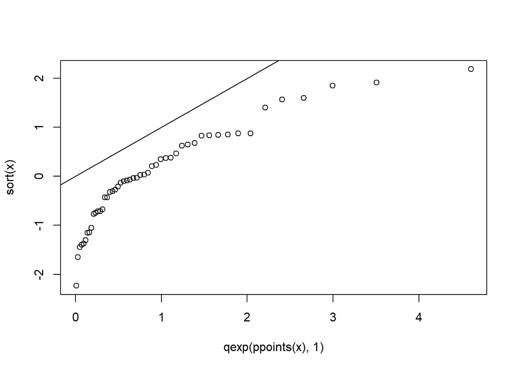

```r
plot(qexp(ppoints(x),1),sort(x))
abline(0,1)
```

Examine the help for the function qqnorm.  
## 7.9. Compare the two samples with a QQ plot

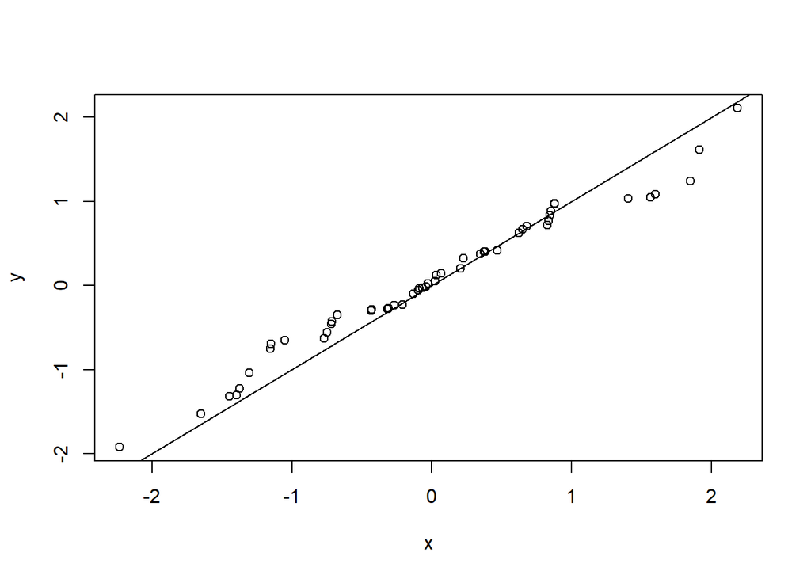

```r
qqplot(x,y)
abline(0,1)
```

## 7.10. Compare the two samples with box plots

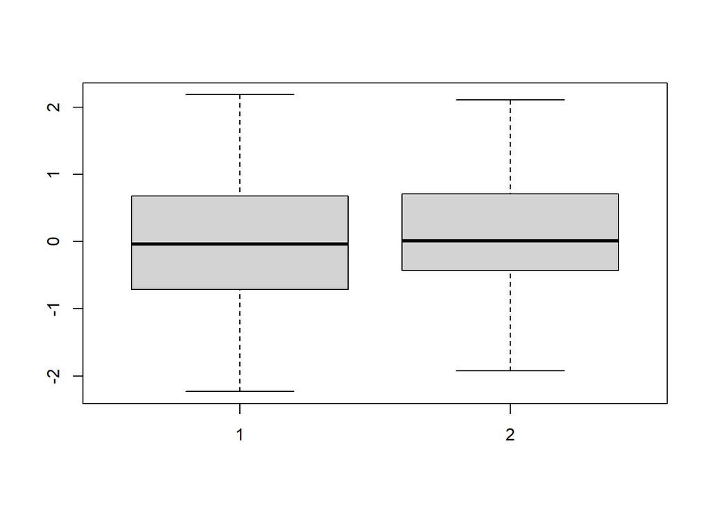

```r
boxplot(x,y)
```

## 7.11. A simple alternative to display the two samples

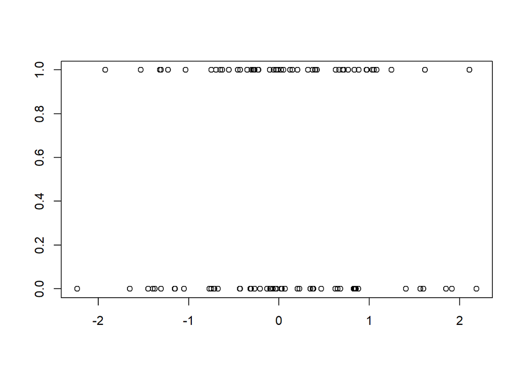

```r
plot(c(x,y),rep(0:1,c(length(x),length(y))),xlab="",ylab="")
```

## 7.12. Plot a histogram of x and a box plot of y, in the same figure.

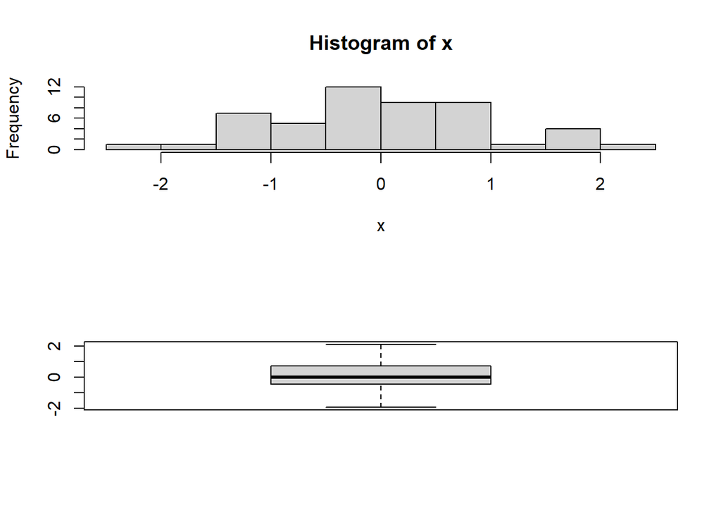

```r
par(mfrow=c(2,1))
hist(x)
boxplot(y)
```

# 7.Problems  
##Examine the built in ChickWeight data (the help gives background about the data). The function split will prove useful to do the following (as will a script)  
##a - Método 1

```r
dura <- ChickWeight
attach(dura)
n <- 413
df2 <- dura[row.names(dura) %in% (n+1):nrow(dura), ]
df3 <- df2[row.names(df2) %in% (414+10):nrow(df2), ]
plot(time,weight, data = df3)
```

##b Método 2

```r
dura1 <- filter(dura,Diet==4)
```

##c Método 3

```r
dura2 <- dura %>% mutate(Chick = as.numeric(Chick)) %>% filter(Chick < 14)
?mean
mean(dura2$weight)
ggplot(data = dura2)+ aes(Time,weight)+
  geom_smooth()
```

# Exercise 8

## 8.1.Write an R expression to determine if two sets, A and B, represented as integer vectors are disjoint. If they are disjoint, display elements of set A otherwise display elements of set B. (Examine thehelp for functions print and cat)

```r
A <- 1:100
print(A)
```

```
##   [1]   1   2   3   4   5   6   7   8   9  10  11  12  13  14  15  16  17  18
##  [19]  19  20  21  22  23  24  25  26  27  28  29  30  31  32  33  34  35  36
##  [37]  37  38  39  40  41  42  43  44  45  46  47  48  49  50  51  52  53  54
##  [55]  55  56  57  58  59  60  61  62  63  64  65  66  67  68  69  70  71  72
##  [73]  73  74  75  76  77  78  79  80  81  82  83  84  85  86  87  88  89  90
##  [91]  91  92  93  94  95  96  97  98  99 100
```

```r
B <- 101:200
print(B)
```

```
##   [1] 101 102 103 104 105 106 107 108 109 110 111 112 113 114 115 116 117 118
##  [19] 119 120 121 122 123 124 125 126 127 128 129 130 131 132 133 134 135 136
##  [37] 137 138 139 140 141 142 143 144 145 146 147 148 149 150 151 152 153 154
##  [55] 155 156 157 158 159 160 161 162 163 164 165 166 167 168 169 170 171 172
##  [73] 173 174 175 176 177 178 179 180 181 182 183 184 185 186 187 188 189 190
##  [91] 191 192 193 194 195 196 197 198 199 200
```

```r
funcao8 <- function(number) {
  ifelse(any(number<100),
         print("Entre 1 e 100 logo pertence a A"),print("Entre 101 e 200 logo pertence a B"))
}
funcao8(2)
```

```
## [1] "Entre 1 e 100 logo pertence a A"
```

```
## [1] "Entre 1 e 100 logo pertence a A"
```

## 8.2.Write R codes that takes the coefficients of a quadratic equation, and outputs an appropriate message for the cases of (i). two distinct roots (b² − 4ac > 0) (ii) coincident roots (b² = 4ac) or (iii). complex roots (b² < 4ac)

Output appropriate message based on discriminant

```r
numero2funcao <- function(a,b,c){
  diferenciador <- b^2 - 4*a*c
    if (diferenciador > 0) {
  raiz1 <- (-b + sqrt(diferenciador))/(2*a)
  raiz2 <- (-b - sqrt(diferenciador))/(2*a)
  cat("The quadratic equation has two distinct roots: ", raiz1, " and ", raiz2, ".\n")
} else if (diferenciador == 0) {
  raiz <- -b/(2*a)
  cat("The quadratic equation has coincident roots: ", raiz, ".\n")
} else {
  real_part <- -b/(2*a)
  imaginary_part <- sqrt(-diferenciador)/(2*a)
  cat("The quadratic equation has complex roots: ", real_part, "+", imaginary_part, "i and ", real_part, "-", imaginary_part, "i.\n")
}}
numero2funcao(1,4,4)
```

```
## The quadratic equation has coincident roots:  -2 .
```

## 8.3. Let vector y be the logarithm of a random sample from a standard normal distribution, N(0, 1). Use the ifelse function to replace missing values with the value 9999.

```r
set.seed(1234)
t <- runif(10, min = 0, max = 1)
t[2:3] <- NA
t <- ifelse(is.na(t), 9999, t)
t
```

```
##  [1] 1.137034e-01 9.999000e+03 9.999000e+03 6.233794e-01 8.609154e-01
##  [6] 6.403106e-01 9.495756e-03 2.325505e-01 6.660838e-01 5.142511e-01
```

## 8.4. Let n be a large integer. Compute a vector x containing n random uniform deviates. Embed the following code in the system.time function for (i in 1:n) y[i] <- sin mes. Now, time the call y <- sin(x) Which is faster?

```r
n <- 1000000
x <- runif(n)
y <- numeric(n)
system.time(for (i in 1:n) y[i] <- sin(x[i]))
```

```
##   usuário   sistema decorrido
##      0.16      0.00      0.17
```

```r
system.time(y <- sin(x))
```

```
##   usuário   sistema decorrido
##      0.05      0.00      0.05
```

Reposta o calculo diretemente sem o loop, ou seja, a segunda  
## 8.5. Compound interest can be computed using the formula A = P × (1 + R/100)n where P is the original money lent, A is what it amounts to in n years at R percent per year interest. Write R code to calculate the amount of money owed after n years, where n changes from 1 to 15 in yearly increments, if the money lent originally is 5000 pounds and the interest rate remains constant throughout the period at 11.5%.  
### Volume inicial emprestado

```r
inicial <- 5000
```

Taxa de Juros

```r
juros <- 0.115
anos <- 1:15
```

calculate the amount owed for each year

```r
valor_total <- inicial * (1 + juros) ^ anos
```

print the results

```r
for (i in 1:length(valor_total)) {
  cat("Depois", anos[i], "anos, o Valor Total é:", round(valor_total[i], 2), "pounds\n")
}
```

```
## Depois 1 anos, o Valor Total é: 5575 pounds
## Depois 2 anos, o Valor Total é: 6216.12 pounds
## Depois 3 anos, o Valor Total é: 6930.98 pounds
## Depois 4 anos, o Valor Total é: 7728.04 pounds
## Depois 5 anos, o Valor Total é: 8616.77 pounds
## Depois 6 anos, o Valor Total é: 9607.7 pounds
## Depois 7 anos, o Valor Total é: 10712.58 pounds
## Depois 8 anos, o Valor Total é: 11944.53 pounds
## Depois 9 anos, o Valor Total é: 13318.15 pounds
## Depois 10 anos, o Valor Total é: 14849.73 pounds
## Depois 11 anos, o Valor Total é: 16557.45 pounds
## Depois 12 anos, o Valor Total é: 18461.56 pounds
## Depois 13 anos, o Valor Total é: 20584.64 pounds
## Depois 14 anos, o Valor Total é: 22951.87 pounds
## Depois 15 anos, o Valor Total é: 25591.34 pounds
```

## 8.6. Write a loop structure to scan through an integer vector to determine the index of the maximum value. The loop should terminate as soon as the index is obtained. (Don’t worry about ties). Of course, this is not a good way to do this! Examine the help for the rank, sort and order functions.

create a vector of integers

```r
x <- c(59, 82, 3111, 211111, 101, 62, 45)
```

initialize variables

```r
maior_valor <- x[i]
valor_index <- i
```

loop through the vector to find the maximum value and its index

```r
for (i in 1:length(x)) {
  if (x[i] > maior_valor) {
    maior_valor <- x[i]
    valor_index <- i
    break
  }
}
```

print the result

```r
cat("A posição do maior valor é:",valor_index, "\n")
```

[output not shown]

# Problemas exercícios Microeconometrics with R

## Chapter 1

## Create the following simulated data.

## 1.1.N = 100 (100 data points)

## 1.2.x ~ U[0,1] (uniformly distributed between 0 and 1)

## 1.3.u ~ N(0,2) (normally distributed with a variance of 2)

## 1.4.y = a + b*x + u, where a = -2, b = 3.

## 2.Run ordinary least squares on the data created in (1). Present estimates for a and b. Discuss why they are or are not close to the true values.

Criando um banco de dados

```r
set.seed(123)
#Linhas de 1 a 100
N <- 100
#y = a + bx + v supondo que a=2 e b=3 sejam os parametros da populacao
a <- -2
b <- 3
#Amostra aleatoria dos valores de x
x <- runif(N)
#Vetor aleatorio do termo de erro v
u <- rnorm(N)
#Criando o vetor y
y <- a + b*x + u
head(y)
```

```
## [1] -0.8839489  0.3363687 -0.8159397  2.0176545  0.5956309 -0.3468599
```

```r
##3.Repeat (2) with N = 1000.  Discuss how the estimates of a and b are different (or the same) from (2).
#Linhas de 1 a 1000
N <- 1000
#y = a + bx + v supondo que a=2 e b=3 sejam os parametros da populacao
a <- -2
b <- 3
#Amostra aleatoria dos valores de x
x <- runif(N)
#Vetor aleatorio do termo de erro v
v <- rnorm(N)
#Criando o vetor y
y <- a + b*x + v
head(y)
```

```
## [1] -1.5847789 -1.8645199  0.9459767 -1.2626524  0.3710212 -1.3854418
```

```r
#Comparando as medias de y e x
mean(y[x>0.95]) - mean(y[x<0.05])
```

```
## [1] 2.746811
```

## 4.Download the data for Using Geographic Variation in College Proximity to Estimate Returns to Schooling by David Card (http://www.nber.org/papers/w4483). The data is available here: http://davidcard.berkeley.edu/data_sets.html. Also available here: Google Sheets

```r
data <- readxl::read_xlsx("nls.xlsx")
```

## 4.1.Plot log wages in 1976 on number of years of education in 1976.

Tratando os dados

```r
data$wage76 <- as.numeric(data$wage76)
```

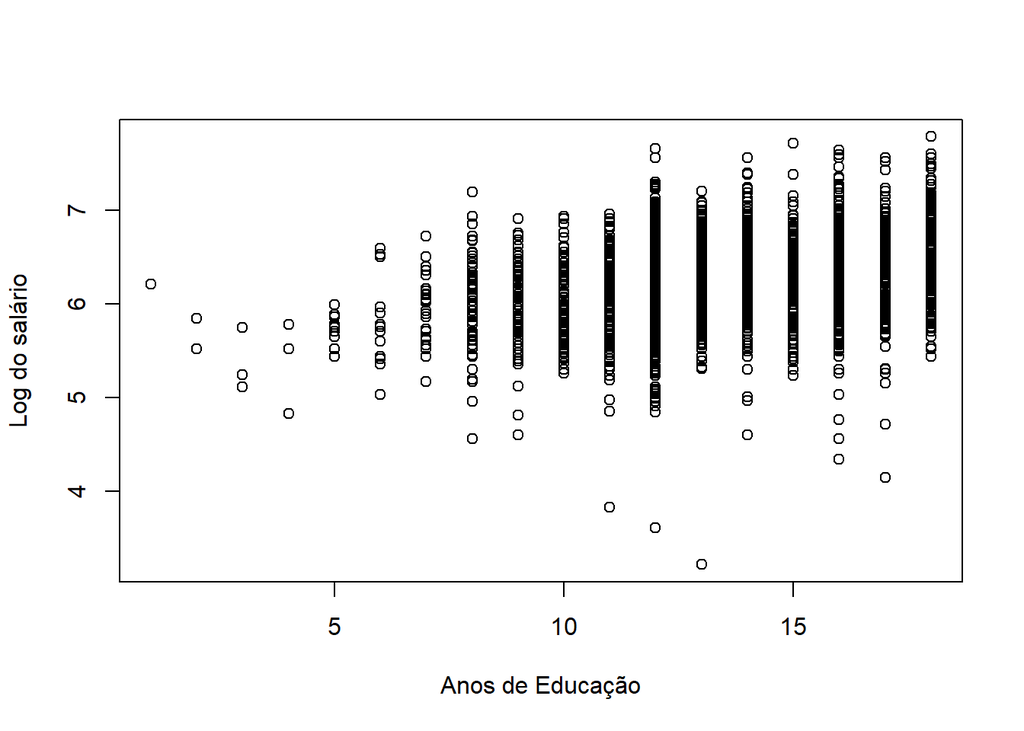

```r
data$ed76 <- as.numeric(data$ed76)
data$lwage76 <- log(data$wage76)
dados <- data[is.na(data$lwage76)==0,]
###Plotando
plot(dados$ed76, dados$lwage76, data = dados, xlab = "Anos de Educação", ylab = "Log do salário")
```

```r
##4.2.Run OLS of log wages in 1976 on number of years of education in 1976.
regcap1 <- lm(data = dados, lwage76 ~ ed76)
summary(regcap1)
```

```
##
## Call:
## lm(formula = lwage76 ~ ed76, data = dados)
##
## Residuals:
##      Min       1Q   Median       3Q      Max
## -3.02410 -0.27636  0.02801  0.29058  1.46581
##
## Coefficients:
##             Estimate Std. Error t value Pr(>|t|)
## (Intercept) 5.567269   0.040017  139.12   <2e-16 ***
## ed76        0.051978   0.002957   17.57   <2e-16 ***
## ---
## Signif. codes:  0 '***' 0.001 '**' 0.01 '*' 0.05 '.' 0.1 ' ' 1
##
## Residual standard error: 0.4349 on 3015 degrees of freedom
## Multiple R-squared:  0.09293,    Adjusted R-squared:  0.09263
## F-statistic: 308.9 on 1 and 3015 DF,  p-value: < 2.2e-16
```

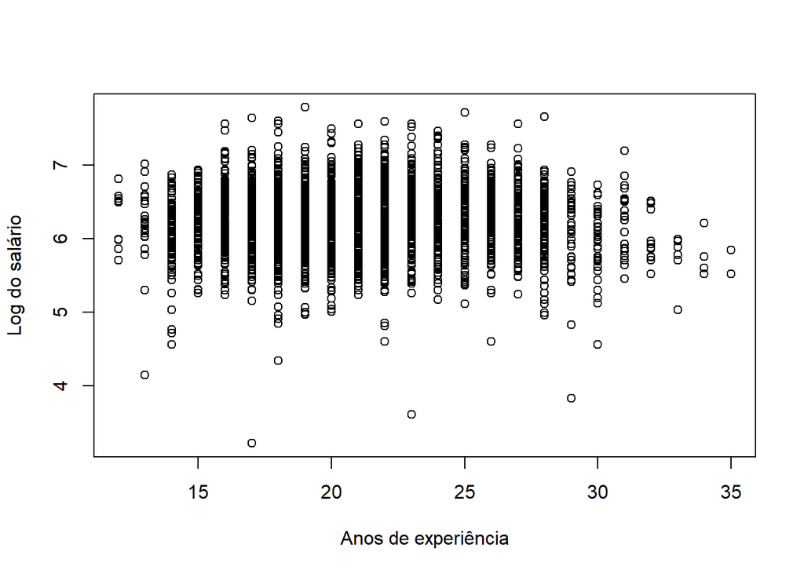

```r
##4.3.Plot log wages in 1976 on work experience (measured as age less years of education plus 6 years).
### Tratando os dados
dados$wexp76 = dados$age76 - dados$ed76 + 6
###Plotando
plot(dados$wexp76 , dados$lwage76, data = dados, xlab = "Anos de experiência", ylab = "Log do salário")
```

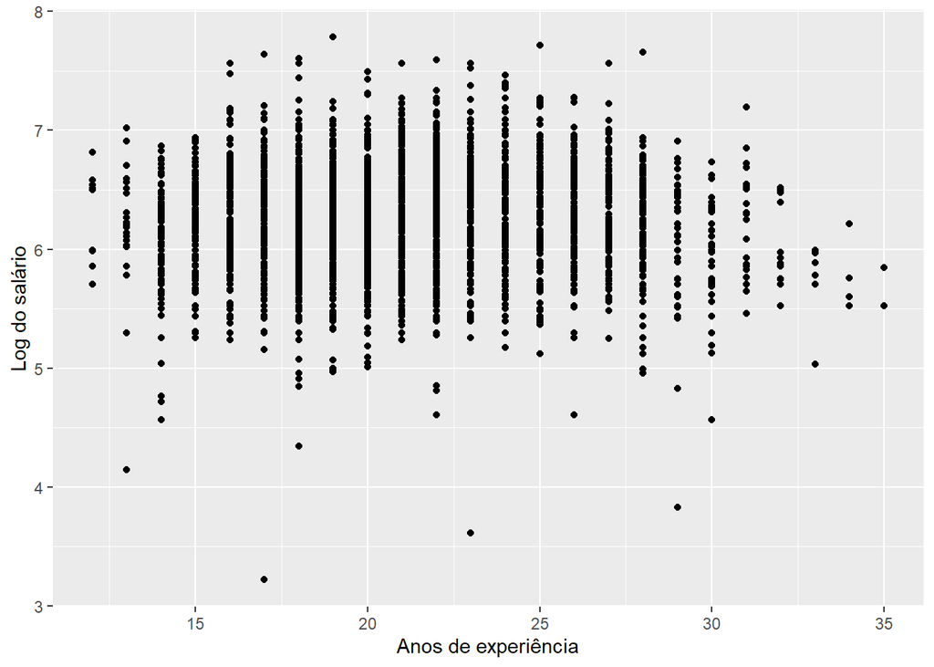

```r
ggplot(data = dados)+
         aes(wexp76, lwage76)+
         geom_point()+
         xlab("Anos de experiência")+ ylab("Log do salário")
```

## 4.4.Run OLS of log wages in 1976 on experience in 1976.

```r
regcap12 <- lm(data = dados, lwage76 ~ wexp76)
summary(regcap12)
```

```
##
## Call:
## lm(formula = lwage76 ~ wexp76, data = dados)
##
## Residuals:
##     Min      1Q  Median      3Q     Max
## -3.0323 -0.2879  0.0268  0.3041  1.5308
##
## Coefficients:
##             Estimate Std. Error t value Pr(>|t|)
## (Intercept) 6.227136   0.042618 146.114   <2e-16 ***
## wexp76      0.001416   0.002004   0.707     0.48
## ---
## Signif. codes:  0 '***' 0.001 '**' 0.01 '*' 0.05 '.' 0.1 ' ' 1
##
## Residual standard error: 0.4566 on 3015 degrees of freedom
## Multiple R-squared:  0.0001656,  Adjusted R-squared:  -0.000166
## F-statistic: 0.4994 on 1 and 3015 DF,  p-value: 0.4798
```

## Chapter 2

## 1.Create the following simulated data.

## 1.1.x ~ U[0,1] (uniformly distributed)

```r
set.seed(123)
N <- 50
x <- round(runif(N))
x
```

```
##  [1] 0 1 0 1 1 0 1 1 1 0 1 0 1 1 0 1 0 0 0 1 1 1 1 1 1 1 1 1 0 0 1 1 1 1 0 0 1 0
## [39] 0 0 0 0 0 0 0 0 0 0 0 1
```

```r
##1.2.w ~ U[0,1] + d*x, where d = 3  (uniformly distributed between 0 and 1 + the effect of x)
x <- round(runif(N))
a <- 1
b <- 2
c <- -3
d <- 3
w_u <- runif(N)
w_u
```

```
##  [1] 0.59998896 0.33282354 0.48861303 0.95447383 0.48290240 0.89035022
##  [7] 0.91443819 0.60873498 0.41068978 0.14709469 0.93529980 0.30122890
## [13] 0.06072057 0.94772694 0.72059627 0.14229430 0.54928466 0.95409124
## [19] 0.58548335 0.40451028 0.64789348 0.31982062 0.30772001 0.21976763
## [25] 0.36948887 0.98421920 0.15420230 0.09104400 0.14190691 0.69000710
## [31] 0.61925648 0.89139412 0.67299909 0.73707774 0.52113573 0.65983845
## [37] 0.82180546 0.78628155 0.97982192 0.43943154 0.31170220 0.40947495
## [43] 0.01046711 0.18384952 0.84272932 0.23116178 0.23909996 0.07669117
## [49] 0.24572368 0.73213521
```

```r
w <- d*x + w_u
w
```

```
##  [1] 0.59998896 0.33282354 3.48861303 0.95447383 3.48290240 0.89035022
##  [7] 0.91443819 3.60873498 3.41068978 0.14709469 3.93529980 0.30122890
## [13] 0.06072057 0.94772694 3.72059627 0.14229430 3.54928466 3.95409124
## [19] 3.58548335 0.40451028 3.64789348 3.31982062 3.30772001 0.21976763
## [25] 0.36948887 0.98421920 0.15420230 3.09104400 0.14190691 0.69000710
## [31] 0.61925648 3.89139412 0.67299909 3.73707774 0.52113573 0.65983845
## [37] 3.82180546 3.78628155 3.97982192 0.43943154 0.31170220 3.40947495
## [43] 0.01046711 3.18384952 0.84272932 0.23116178 3.23909996 0.07669117
## [49] 0.24572368 3.73213521
```

```r
##1.3.e ~ N(0,1)  (normally distributed with a variance of 1)
e <- rnorm(N)
e
```

```
##  [1]  1.025571370 -0.284773007 -1.220717712  0.181303480 -0.138891362
##  [6]  0.005764186  0.385280401 -0.370660032  0.644376549 -0.220486562
## [11]  0.331781964  1.096839013  0.435181491 -0.325931586  1.148807618
## [16]  0.993503856  0.548396960  0.238731735 -0.627906076  1.360652449
## [21] -0.600259587  2.187332993  1.532610626 -0.235700359 -1.026420900
## [26] -0.710406564  0.256883709 -0.246691878 -0.347542599 -0.951618567
## [31] -0.045027725 -0.784904469 -1.667941937 -0.380226520  0.918996609
## [36] -0.575346963  0.607964322 -1.617882708 -0.055561966  0.519407204
## [41]  0.301153362  0.105676194 -0.640706008 -0.849704346 -1.024128791
## [46]  0.117646597 -0.947474614 -0.490557444 -0.256092192  1.843862005
```

```r
##1.4.y = a + b*x + c*w + e, where a = 1, b = 0, c = -3
y = a + b*x + c*w + e
y
```

```
##  [1]  0.225604492 -0.283243628 -8.686556813 -1.682118003 -7.587598554
##  [6] -1.665286480 -1.358034160 -8.196864979 -6.587692781  0.338229365
## [11] -8.474117446  1.193152313  1.253019776 -2.169112406 -7.012981202
## [16]  1.566620969 -7.099457009 -8.623541981 -8.384356135  1.147121603
## [21] -8.543940025 -4.772128858 -5.390549406  0.104996747 -1.134887498
## [26] -2.663064174  0.794276807 -6.519823878  0.226736677 -2.021639872
## [31] -0.902797175 -9.459086821 -2.686939214 -8.591459734  0.355589432
## [36] -1.554862312 -7.857452058 -9.976727363 -8.995027718  0.201112595
## [41]  0.366046756 -7.122748664  0.327892656 -7.401252918 -2.552316747
## [46]  0.424161251 -7.664774481  0.279369060  0.006736774 -6.352543611
```

```r
##1.5.N = 50 (50 data points)
##1.6.Run ordinary least squares on the relationship between y and x (y as a function of x).  Present the estimates of b.  Discuss why it is or is not close to the true value.
shortreg <- lm(y ~ x)
summary(shortreg)
```

```
##
## Call:
## lm(formula = y ~ x)
##
## Residuals:
##     Min      1Q  Median      3Q     Max
## -2.2812 -0.9328  0.2173  0.7750  2.9234
##
## Coefficients:
##             Estimate Std. Error t value Pr(>|t|)
## (Intercept)  -0.4237     0.2427  -1.746   0.0873 .
## x            -7.2718     0.3659 -19.873   <2e-16 ***
## ---
## Signif. codes:  0 '***' 0.001 '**' 0.01 '*' 0.05 '.' 0.1 ' ' 1
##
## Residual standard error: 1.284 on 48 degrees of freedom
## Multiple R-squared:  0.8916, Adjusted R-squared:  0.8894
## F-statistic:   395 on 1 and 48 DF,  p-value: < 2.2e-16
```

```r
##1.7.Draw the causal diagrams representing this data generating process.

##1.8.Run ordinary least squares on the relationship between y and all of x and w.  Present the estimates of b.  Discuss why the it is or is not close to the true value.
###Obtendo manualmente os coeficiente de cada relacao
e_hat <- shortreg$coefficients[2]
c_hat <- lm(y ~ w)$coef[2]
d_hat <- lm(w ~ x)$coef[2]

###A estimativa de b
e_hat - c_hat*d_hat
```

```
##         x
## 0.1012377
```

```r
e_hat
```

```
##         x
## -7.271784
```

```r
##1.9.Can you show that b must be equal to zero?  Show your test.
sum(b)
```

```
## [1] 2
```

```r
summary(b)
```

```
##    Min. 1st Qu.  Median    Mean 3rd Qu.    Max.
##       2       2       2       2       2       2
```

## 2.Download the data for Mortgage Lending in Boston. Available here: HMDA data (Google Sheets)

x <- readxl::read_xlsx(“hmda_aer.xlsx”) ## 2.1.Create variables for mortgage denials, race, income, credit worthiness.  
## 2.3.Using ordinary least squares can you show that there is evidence that banks are illegally denying mortgages based on race? Or that there is evidence that banks are behaving legally? Explain your method. Explain the concerns with your analysis.

```r
library(readxl)
x <- read_xlsx("hmda_aer.xlsx")
x$deny <- ifelse(x$s7==3,1,ifelse(x$s7==1 | x$s7==2,0,NA))
x$black <- as.numeric(x$s13==3)

#Salarios
x$lwage <- NA
x$wage <- ifelse(x$s31a == 0, NA, x$s31a)
x$lwage <- log(x$wage)

#Pefil de pagamento no sistema bancario
x$mhist <- x$s42

#Perfil pagamento do consumidor
x$chist <- x$s43

#Pefil de pagamento de emprestimos publico
x$phist <- x$s44

#Tempo empregado
x$emp <- x$s25a
x$emp <- ifelse(x$emp > 1000,NA,x$emp)

#Definindo as matrizes
Y1 <- x$deny
X1 <- cbind(1,x$black)
W1 <- cbind(1, x$lwage, x$chist,
            x$mhist, x$phist, x$emp)

#Excluindo as linhas com NAs
index <- is.na(rowSums(cbind(Y1,X1,W1)))==0

#Redefinindo as matrizes sem NAs
X2 <- X1[index,]
W2 <- W1[index,]
Y2 <- Y1[index]

#Estimando as matrizes dos coeficientes
beta_tilde_hat <- solve(t(X2)%*%X2)%*%t(X2)%*%Y2
delta_hat <- solve(t(X2)%*%X2)%*%t(X2)%*%W2
gamma_hat <- solve(t(W2)%*%W2)%*%t(W2)%*%Y2
beta_hat <- beta_tilde_hat - delta_hat%*%gamma_hat

#Incluindo mais variaveis
x$married <- as.numeric(x$s23a == "M")

#Participacao das despesas na renda
x$dr <- ifelse(x$s45 > 999999, NA, x$s45)

#Linhas de credito
x$clines <- ifelse(x$s41 > 999999, NA, x$s41)

#Sexo
x$male <- as.numeric(x$s15 == 1)

#(S11) County
x$suff <- ifelse(x$s11 > 999999, NA, x$s11)

#(S35) Liquid assets (in thousands)
x$assets <- ifelse(x$s35 > 999999, NA, x$s35)

#(S6) Loan amount (in thousands)
x$s6 <- ifelse(x$s6 > 999999, NA, x$s6)

#(S50) Appraised value (in thousands)
x$s50 <- ifelse(x$s50 > 999999, NA, x$s50)

#(S33) Purchase price (in thousands)
x$s33 <- ifelse(x$s33 > 999999, NA, x$s33)

#(S6) Loan amount (in thousands)
x$lr <- x$s6/x$s50
x$pr <- x$s33/x$s50

#(S16) Co-applicant sex
x$coap <- x$s16==4
x$school <- ifelse(x$school > 999999, NA, x$school)

#Times application was reviewed by underwriter
x$s57 <- ifelse(x$s57 > 999999, NA, x$s57)

#(S48) Term of loan (months)
x$s48 <- ifelse(x$s48 > 999999, NA, x$s48)

#(S39) Number of commercial credit reports
x$s39 <- ifelse(x$s39 > 999999, NA, x$s39)

#(chvalc) Change in median value of
#property in a given tract, 1980-1990
x$chval <- ifelse(x$chval > 999999, NA, x$chval)

#(S20) Number of units in property purchased
x$s20 <- ifelse(x$s20 > 999999, NA, x$s20)
x$lwage_coap <- NA

#(S31C) Total monthly income of coapplicant ($)
x[x$s31c > 0 & x$s31c < 999999,]$lwage_coap <-
  log(x[x$s31c > 0 & x$s31c < 999999,]$s31c)
x$lwage_coap2 <- ifelse(x$coap==1,x$lwage_coap,0)
x$male_coap <- x$s16==1

#Redefinindo nosso W1
W1 <- cbind(1,x$lwage,x$chist,x$mhist,x$phist,x$emp,
            x$emp^2,x$married,x$dr,x$clines,x$male,
            x$suff,x$assets,x$lr,x$pr,x$coap,x$s20,
            x$s24a,x$s27a,x$s39,x$s48,x$s53,x$s55,x$s56,
            x$s57,x$chval,x$school,x$bd,x$mi,x$old,
            x$vr,x$uria,x$netw,x$dnotown,x$dprop,
            x$lwage_coap2,x$lr^2,x$pr^2,x$clines^2,x$rtdum)

#Eliminando NAs
index <- is.na(rowSums(cbind(Y1,X1,W1)))==0
X2 <- X1[index,]
W2 <- W1[index,]
Y2 <- Y1[index]

#Estimando as matrizes dos coeficientes
beta_tilde_hat <- solve(t(X2)%*%X2)%*%t(X2)%*%Y2
delta_hat <- solve(t(X2)%*%X2)%*%t(X2)%*%W2
gamma_hat <- solve(t(W2)%*%W2)%*%t(W2)%*%Y2
beta_hat <- beta_tilde_hat - delta_hat%*%gamma_hat
##2.2.Run ordinary least squares on the relationship between mortgage denials and race.  Does this provide evidence that banks are acting illegally?
#Bootstrap
set.seed(123456)
K <- 1000
bs_mat <- matrix(NA,K,2)

for (k in 1:K) {
  index_k <- round(runif(length(Y2),min = 1, max = length(Y2)))
  Y3 <- Y2[index_k]
  X3 <- X2[index_k,]
  W3 <- W2[index_k,]
  beta_tilde_hat <- solve(t(X3)%*%X3)%*%t(X3)%*%Y3
  delta_hat <- solve(t(X3)%*%X3)%*%t(X3)%*%W3
  gamma_hat <- solve(t(W3)%*%W3)%*%t(W3)%*%Y3
  bs_mat[k,] <- beta_tilde_hat - delta_hat%*%gamma_hat
}

#Inserindo valores na tabela
tab_res <- matrix(NA,2,4)
tab_res[,1] <- colMeans(bs_mat)
tab_res[,2] <- apply(bs_mat,2,sd)
tab_res[1,3:4] <- quantile(bs_mat[,1], c(0.025,0.975))
tab_res[2,3:4] <- quantile(bs_mat[,2], c(0.025,0.975))
colnames(tab_res) <- c("Estimate",'SD', "2.5%","97.5%")
tab_res
```

```
##          Estimate          SD         2.5%       97.5%
## [1,] -0.003745227 0.002665051 -0.009165300 0.001520998
## [2,]  0.024434643 0.017331181 -0.009552775 0.059422281
```

##3.Download the data for Using Geographic Variation in College Proximity to Estimate Returns to Schooling by David Card (http://www.nber.org/papers/w4483). The data is available here: http://davidcard.berkeley.edu/data_sets.html. Also available here: Google Sheets

```r
library(readxl)
nls <- read_xlsx("nls.xlsx")
```

## 3.1.Replicate Table 2 of the paper (to the extent you can with the data). Note that you need to read the paper carefully to determine the definitions of the variables.

#Lendo variaveis como numericas

```r
nls$lwage76 <- as.numeric(nls$lwage76)
nls1 <- nls[is.na(nls$lwage76)==0,]

#Criando variaveis
nls1$exp <- nls1$age76 - nls1$ed66 - 6
nls1$exp2 <- (nls1$exp^2)/100

#Estimativa OLS
regca22 <- lm(lwage76 ~ ed76 + exp + exp2 + black +reg76r + smsa76r + smsa66r
          + reg662 + reg663 + reg664 + reg665 + reg666 + reg667 + reg668
          + reg669, data = nls1)
summary(regca22)
```

```
##
## Call:
## lm(formula = lwage76 ~ ed76 + exp + exp2 + black + reg76r + smsa76r +
##     smsa66r + reg662 + reg663 + reg664 + reg665 + reg666 + reg667 +
##     reg668 + reg669, data = nls1)
##
## Residuals:
##      Min       1Q   Median       3Q      Max
## -1.81065 -0.24628  0.01562  0.26373  1.26516
##
## Coefficients:
##              Estimate Std. Error t value Pr(>|t|)
## (Intercept)  4.798246   0.151877  31.593  < 2e-16 ***
## ed76         0.048146   0.003318  14.510  < 2e-16 ***
## exp          0.093522   0.021201   4.411 1.06e-05 ***
## exp2        -0.249764   0.078954  -3.163  0.00157 **
## black       -0.209767   0.019118 -10.972  < 2e-16 ***
## reg76r      -0.150662   0.027230  -5.533 3.42e-08 ***
## smsa76r      0.130638   0.021060   6.203 6.29e-10 ***
## smsa66r      0.034323   0.020383   1.684  0.09231 .
## reg662       0.085686   0.037677   2.274  0.02302 *
## reg663       0.132114   0.036830   3.587  0.00034 ***
## reg664       0.054450   0.043719   1.245  0.21306
## reg665       0.108073   0.043835   2.465  0.01374 *
## reg666       0.113983   0.047398   2.405  0.01624 *
## reg667       0.104467   0.046967   2.224  0.02621 *
## reg668      -0.059986   0.053728  -1.116  0.26431
## reg669       0.116536   0.040715   2.862  0.00424 **
## ---
## Signif. codes:  0 '***' 0.001 '**' 0.01 '*' 0.05 '.' 0.1 ' ' 1
##
## Residual standard error: 0.3902 on 2994 degrees of freedom
## Multiple R-squared:  0.2308, Adjusted R-squared:  0.2269
## F-statistic: 59.89 on 15 and 2994 DF,  p-value: < 2.2e-16
```

## 3.2.How should we interpret the estimates for row (1) Education and (2) Experience?

Ambas têm graus de relevância superiores a 0.001%, ou seja, existe uma chance muito pequena de se incorrer em erro do tipo 1. Ao mesmo experiencia parece ser mais relevante para determinar o nível de salário dos indivíduos (sem levar em consideração o efeito negativo de exp^2 é claro).

##3.3.What concerns should we have about these estimates for determining the value of a policy that subsidizes college?  
É necessário tanto se ater tanto a disparidade racial (evidenciada em black), as questões regionais (de localização) e a escolaridade dos pais, objetivando diminuir as disparidades.

## Chapter 3

##1.Create the following simulated data.  
##1.1.x ~ a binary variable, where Prob(x=1) = 0.2 (20% are 1s)  
##1.2.w ~ U[0,1] + dx, where d = 3 (uniformly distributed between 0 and 1 + the effect of x)  
##1.3.z ~ U[0,1] + fx, where f = 2  
##1.4.e ~ N(0,1) (normally distributed with a variance of 1)

```r
set.seed(123)
N <- 50
x <- rbinom(N, 1, 0.2)
a <- 1
b <- 0
c <- -3
d <- 3
e <- rnorm(N, mean = 0, sd = 1)
f <- 2
g <- -2
w <- runif(N) + d*x
z <- runif(N) + f*x
```

## 1.5.y = a + b*x + c*w + g*z + e, where a = 1, b = 0, c = -3, g = -2

##1.6.N = 50 (50 data points)

```r
y = a + b*x + c*w + g*z + e
head(y)
```

```
## [1]  -3.706505  -1.579513  -1.213085 -14.907543 -11.884621  -1.504012
```

## 1.7.Run ordinary least squares on the relationship between y and x (y as a function of x). Present the estimates of b. Discuss why it is or is not close to the true value.

```r
regcap3 <- lm(y ~ x)
summary(regcap3)
```

```
##
## Call:
## lm(formula = y ~ x)
##
## Residuals:
##      Min       1Q   Median       3Q      Max
## -2.83217 -0.66658 -0.04988  0.70679  2.46846
##
## Coefficients:
##             Estimate Std. Error t value Pr(>|t|)
## (Intercept)  -1.5521     0.1918  -8.094 1.59e-10 ***
## x           -12.8010     0.4088 -31.311  < 2e-16 ***
## ---
## Signif. codes:  0 '***' 0.001 '**' 0.01 '*' 0.05 '.' 0.1 ' ' 1
##
## Residual standard error: 1.198 on 48 degrees of freedom
## Multiple R-squared:  0.9533, Adjusted R-squared:  0.9524
## F-statistic: 980.4 on 1 and 48 DF,  p-value: < 2.2e-16
```

## 1.8.Draw the causal diagrams representing this data generating process.

## 1.9.Run ordinary least squares on the relationship between y and all of x, w and z. Present the estimates of b. Discuss why the it is or is not close to the true value.

```r
regcap32 <- lm(y ~ x + w)
head(y)
```

```
## [1]  -3.706505  -1.579513  -1.213085 -14.907543 -11.884621  -1.504012
```

## 2.Create the following simulated data.

## 2.1.z ~ U[0,1] (uniformly distributed between 0 and 1)

## 2.2.u ~ N(0,2) (normally distributed with a variance of 2)

## 2.3.e ~ N(0,1)

## 2.4.x = c + d*u + f*z + e, where c = -4, d = -2, f = 2

## 2.5.y = a + b*x + u, where a = 3, b = -2.

## 2.6.N = 1000 (1000 data points)

```r
library(LaplacesDemon)
set.seed(123)
N <- 1000
a <-  3
b <-  -2
c <-  -4
d <-  -2
e <-  rnorm(N, mean = 0, sd = 1)
f <-  2
u <-  rnormv(N, mean = 0, var = 2)
z <-  - runif(N, min = 0, max = 2)
x <-  c + d*u *f*z + e
y <-  a + b*x + u
head(y)
```

```
## [1] 17.572974 29.587109  8.098679 13.086208 24.098441  5.719543
```

## 2.8.Run ordinary least squares on the relationship between y and x (y as a function of x). Present estimates for a and b. Discuss why they are or are not close to the true values.

```r
regcap33 <- lm(y ~ x)
summary(regcap33)
```

```
##
## Call:
## lm(formula = y ~ x)
##
## Residuals:
##     Min      1Q  Median      3Q     Max
## -3.1904 -0.3331 -0.0188  0.3412  3.6611
##
## Coefficients:
##              Estimate Std. Error t value Pr(>|t|)
## (Intercept)  3.760711   0.026519   141.8   <2e-16 ***
## x           -1.813348   0.003502  -517.9   <2e-16 ***
## ---
## Signif. codes:  0 '***' 0.001 '**' 0.01 '*' 0.05 '.' 0.1 ' ' 1
##
## Residual standard error: 0.7284 on 998 degrees of freedom
## Multiple R-squared:  0.9963, Adjusted R-squared:  0.9963
## F-statistic: 2.682e+05 on 1 and 998 DF,  p-value: < 2.2e-16
```

## 2.9.Run OLS on the relationship between x and z, present estimates for c and f.

```r
regcap34 <- lm(x ~ z)
summary(regcap34)
```

```
##
## Call:
## lm(formula = x ~ z)
##
## Residuals:
##     Min      1Q  Median      3Q     Max
## -29.941  -3.022   0.041   3.314  32.244
##
## Coefficients:
##             Estimate Std. Error t value Pr(>|t|)
## (Intercept)  -3.9567     0.4168  -9.493   <2e-16 ***
## z            -0.2074     0.3691  -0.562    0.574
## ---
## Signif. codes:  0 '***' 0.001 '**' 0.01 '*' 0.05 '.' 0.1 ' ' 1
##
## Residual standard error: 6.583 on 998 degrees of freedom
## Multiple R-squared:  0.0003162,  Adjusted R-squared:  -0.0006855
## F-statistic: 0.3157 on 1 and 998 DF,  p-value: 0.5744
```

## 2.10.Run OLS on the relationship between y and z. How should the coefficient estimate on z be interpreted?

```r
regcap35 <- lm(y ~ z)
summary(regcap35)
```

```
##
## Call:
## lm(formula = y ~ z)
##
## Residuals:
##     Min      1Q  Median      3Q     Max
## -60.042  -5.450  -0.175   5.197  55.515
##
## Coefficients:
##             Estimate Std. Error t value Pr(>|t|)
## (Intercept)  10.9772     0.7572  14.498   <2e-16 ***
## z             0.4186     0.6705   0.624    0.533
## ---
## Signif. codes:  0 '***' 0.001 '**' 0.01 '*' 0.05 '.' 0.1 ' ' 1
##
## Residual standard error: 11.96 on 998 degrees of freedom
## Multiple R-squared:  0.0003904,  Adjusted R-squared:  -0.0006112
## F-statistic: 0.3898 on 1 and 998 DF,  p-value: 0.5326
```

##2.11.Using the results in (h) and (i) to determine the IV estimate of b. Discuss why this estimate is or is not close to the true value of b. ##3.Using matrix algebra, derive the IV estimate.

```r
lm_iv <- function(y, X_in, Z_in=X_in, Reps = 100,
                  min_in = 0.05, max_in = 0.95) {
  set.seed(123456)
  X <- cbind(1, X_in)
  Z <- cbind(1,Z_in)

  bs_mat <- matrix(NA,Reps, dim(X)[2])
  N <- length(y)
  for (r in 1:Reps) {
    index_bs <- round(runif(N, min = 1, max = N))
    y_bs <- y[index_bs]
    X_bs <- X[index_bs,]
    Z_bs <- Z[index_bs,]
    bs_mat[r,] <- solve(t(Z_bs)%*%X_bs)%*%t(Z_bs)%*%y_bs
  }

  tab_res <- matrix(NA, dim(X)[2],4)
  tab_res[,1] <- colMeans(bs_mat)
  for (j in 1:dim(X)[2]) {
    tab_res[j,2] <- sd(bs_mat[,j])
    tab_res[j,3] <- quantile(bs_mat[,j],min_in)
    tab_res[j,4] <- quantile(bs_mat[,j],max_in)
  }
  colnames(tab_res) <- c("coef", "sd",
                         as.character(min_in), as.character(max_in))
  return(tab_res)
}

print(lm_iv(y,x), digits = 3) #OLS
```

```
##       coef      sd  0.05  0.95
## [1,]  3.76 0.02660  3.72  3.81
## [2,] -1.81 0.00306 -1.82 -1.81
```

```r
print(lm_iv(y,x,z), digits = 3) #IV
```

```
##       coef   sd  0.05  0.95
## [1,]  3.39 5.54  2.02  6.58
## [2,] -1.91 1.38 -2.25 -1.07
```

## 4.Create the following simulated data.

## 4.1.x ~ a binary variable, where Prob(x=1) = 0.2 (20% are 1s)

```r
library(LaplacesDemon)
#w ~ U[0,1] + d*x, where d = 3  (uniformly distributed between 0 and 1 + the effect of x)
#z ~ U[0,1] + f*x, where f = 2
#e ~ N(0,1)  (normally distributed with a variance of 1)
#y = a + b*x + c*w + g*z + e, where a = 1, b = 0, c = -3, g = -2
#N = 1000
set.seed(123)
N <- 1000
a <- 1
b <- 0
c <- -3
d <- 3
e <- rnormv(N, mean = 0, var = 1)
f <- 2
g <- -2
x <- rbinom(N, 1, 0.2)
w <- runif(N, min = 0, max = 1) + d*x
z <- runif(N) + d*f
y = a + b*x + c*w + g*z + e
head(y)
```

```
## [1] -12.78688 -15.72343 -11.76656 -14.42261 -12.00932 -11.54473
```

## 4.2.Calculate the OLS estimate based on the matrix algebra in R.

```r
regcap36 <- lm(y ~ x)
summary(regcap36)
```

```
##
## Call:
## lm(formula = y ~ x)
##
## Residuals:
##    Min     1Q Median     3Q    Max
## -4.037 -1.022 -0.033  0.987  4.490
##
## Coefficients:
##             Estimate Std. Error t value Pr(>|t|)
## (Intercept) -13.5194     0.0504 -268.22   <2e-16 ***
## x            -8.7699     0.1136  -77.23   <2e-16 ***
## ---
## Signif. codes:  0 '***' 0.001 '**' 0.01 '*' 0.05 '.' 0.1 ' ' 1
##
## Residual standard error: 1.428 on 998 degrees of freedom
## Multiple R-squared:  0.8566, Adjusted R-squared:  0.8565
## F-statistic:  5964 on 1 and 998 DF,  p-value: < 2.2e-16
```

## 4.3.Calculate the IV estimate based on the matrix algebra in R.

```r
bd_hat <- lm(y ~ z)$coef[2]
d_hat <- lm(x ~ z)$coef[2]
bd_hat/d_hat
```

```
##        z
## 50.45069
```

## 5.Download the data for Using Geographic Variation in College Proximity to Estimate Returns to Schooling by David Card (http://www.nber.org/papers/w4483). The data is available here: Data (Google Sheets)

## 5.1.Replicate Table 3 A (the top part, to the extent you can with the data).

```r
### Aquirvo já carregado anteriormente em outra atividade
#Criando variaveis
### Regressão
regcap37 <- lm(lwage76 ~ ed76 + exp + exp2 + black +reg76r + smsa76r + smsa66r
          + reg662 + reg663 + reg664 + reg665 + reg666 + reg667 + reg668
          + reg669,  data = nls1)
summary(regcap37)
```

```
##
## Call:
## lm(formula = lwage76 ~ ed76 + exp + exp2 + black + reg76r + smsa76r +
##     smsa66r + reg662 + reg663 + reg664 + reg665 + reg666 + reg667 +
##     reg668 + reg669, data = nls1)
##
## Residuals:
##      Min       1Q   Median       3Q      Max
## -1.81065 -0.24628  0.01562  0.26373  1.26516
##
## Coefficients:
##              Estimate Std. Error t value Pr(>|t|)
## (Intercept)  4.798246   0.151877  31.593  < 2e-16 ***
## ed76         0.048146   0.003318  14.510  < 2e-16 ***
## exp          0.093522   0.021201   4.411 1.06e-05 ***
## exp2        -0.249764   0.078954  -3.163  0.00157 **
## black       -0.209767   0.019118 -10.972  < 2e-16 ***
## reg76r      -0.150662   0.027230  -5.533 3.42e-08 ***
## smsa76r      0.130638   0.021060   6.203 6.29e-10 ***
## smsa66r      0.034323   0.020383   1.684  0.09231 .
## reg662       0.085686   0.037677   2.274  0.02302 *
## reg663       0.132114   0.036830   3.587  0.00034 ***
## reg664       0.054450   0.043719   1.245  0.21306
## reg665       0.108073   0.043835   2.465  0.01374 *
## reg666       0.113983   0.047398   2.405  0.01624 *
## reg667       0.104467   0.046967   2.224  0.02621 *
## reg668      -0.059986   0.053728  -1.116  0.26431
## reg669       0.116536   0.040715   2.862  0.00424 **
## ---
## Signif. codes:  0 '***' 0.001 '**' 0.01 '*' 0.05 '.' 0.1 ' ' 1
##
## Residual standard error: 0.3902 on 2994 degrees of freedom
## Multiple R-squared:  0.2308, Adjusted R-squared:  0.2269
## F-statistic: 59.89 on 15 and 2994 DF,  p-value: < 2.2e-16
```

## 5.2.How should we interpret the estimate for education in row (2) (0.132)?

## 6.Create a two-sage IV estimator using matrix algebra and using the bootstrap to create a measure of uncertainty around the estimates. Compare the results the estimator used in (4) and (5).

###Usando matrizes….

```r
#Matricialmente
X <- cbind(1,x)
Z <- cbind(1,z)
beta_hat_ols <- solve(t(X)%*%X)%*%t(X)%*%y
beta_hat_iv <- solve(t(Z)%*%X)%*%t(Z)%*%y

#Bootstrap IV
lm_iv <- function(y, X_in, Z_in=X_in, Reps = 100,
                  min_in = 0.05, max_in = 0.95) {
  set.seed(123456)
  X <- cbind(1, X_in)
  Z <- cbind(1,Z_in)

  bs_mat <- matrix(NA,Reps, dim(X)[2])
  N <- length(y)
  for (r in 1:Reps) {
    index_bs <- round(runif(N, min = 1, max = N))
    y_bs <- y[index_bs]
    X_bs <- X[index_bs,]
    Z_bs <- Z[index_bs,]
    bs_mat[r,] <- solve(t(Z_bs)%*%X_bs)%*%t(Z_bs)%*%y_bs
  }

  tab_res <- matrix(NA, dim(X)[2],4)
  tab_res[,1] <- colMeans(bs_mat)
  for (j in 1:dim(X)[2]) {
    tab_res[j,2] <- sd(bs_mat[,j])
    tab_res[j,3] <- quantile(bs_mat[,j],min_in)
    tab_res[j,4] <- quantile(bs_mat[,j],max_in)
  }
  colnames(tab_res) <- c("coef", "sd",
                         as.character(min_in), as.character(max_in))
  return(tab_res)
}

print(lm_iv(y,x), digits = 3) #OLS
```

```
##        coef     sd   0.05   0.95
## [1,] -13.53 0.0481 -13.62 -13.45
## [2,]  -8.76 0.1215  -8.94  -8.59
```

```r
print(lm_iv(y,x,z), digits = 3) #IV
```

```
##       coef    sd 0.05  0.95
## [1,] -23.7  65.4 -116  23.3
## [2,]  42.6 328.3 -194 476.4
```

```r
y <- nls1$lwage76
X <- cbind(nls1$ed76, nls1$exp, nls1$exp2, nls1$black, nls1$reg76r,
           nls1$smsa76r, nls1$smsa66r, nls1$reg662, nls1$reg663,
           nls1$reg664, nls1$reg665, nls1$reg666, nls1$reg667,
           nls1$reg668, nls1$reg669)
nls1$age2 <- nls1$age76^2
Z1 <- cbind(nls1$nearc4, nls1$age76, nls1$age2, nls1$black,
            nls1$reg76r,nls1$smsa76r, nls1$smsa66r, nls1$reg662,
            nls1$reg663,nls1$reg664, nls1$reg665, nls1$reg666,
            nls1$reg667, nls1$reg668, nls1$reg669)

res <- lm_iv(y,X, Reps=1000)
res <- lm_iv(y,X,Z1, Reps=1000)

rownames(res) <- c("intercept","ed76","exp", "exp2",
                   "black", "reg76r","smsa76r", "smsa66r",
                   "reg662","reg663","reg664", "reg665",
                   "reg666","reg667", "reg668", "reg669")

###Comparando medias para domicilios proximos ou não da escola
tab_cols <- c("Near College", "Not Near College")
tab_rows <- c("ed76", "exp", "black", "south66",
              "smsa66r", "reg76r", "smsa76r")
table_dist <- matrix(NA,7,2)


###Teste de identificacao
Z2 <- cbind(nls1$momdad14, nls1$age76, nls1$age2, nls1$black,
            nls1$reg76r, nls1$smsa76r, nls1$smsa66r, nls1$reg662,
            nls1$reg663, nls1$reg664, nls1$reg665, nls1$reg666,
            nls1$reg667, nls1$reg668, nls1$reg669)

###Bootstrap
set.seed(123)
bs_diff <- matrix(NA,1000,1)
N <- length(y)

for (i in 1:1000) {
  index_bs <- round(runif(N,min = 1,max = N))
  y_bs <- y[index_bs]
  X_bs <- X[index_bs,]
  Z1_bs <- Z1[index_bs,]
  Z2_bs <- Z2[index_bs,]
  bs_diff[i] <- (solve(t(Z1_bs)%*%X_bs)%*%t(Z1_bs)%*%y_bs)[2,1] -
    (solve(t(Z2_bs)%*%X_bs)%*%t(Z2_bs)%*%y_bs)[2,1]
}

summary(bs_diff)
```

```
##        V1
##  Min.   :-2.78221
##  1st Qu.:-0.01216
##  Median : 0.08912
##  Mean   : 0.08024
##  3rd Qu.: 0.18174
##  Max.   : 0.85160
```

```r
quantile(bs_diff,c(0.05, 0.95))
```

```
##         5%        95%
## -0.1977892  0.3551113
```

## Chapter 4

##1. Download the data for Tying Odysseus to the Mast (Google Sheets - dta file). Think of the treatment assignment as an instrument.

```r
####install.packages("readstata13")
library(readstata13)
database1 <- read.dta13("seedanalysis_011204_080404.dta")
```

## .Download the data for Using Geographic Variation in College Proximity to Estimate Returns to Schooling by David Card (http://www.nber.org/papers/w4483). The data is available here: Data (Google Sheets)

##2.1. Split the observations into two groups:  
##2.1.1. Received 12 or few years of education prior to 1976

```r
nls2 <- nls1 %>%
  filter(nls1$ed76 <= 12)
#2.1.2. Received 13 or more years of education prior to 1976
nls3 <- nls1 %>%
  filter(nls1$ed76 >= 13)
#2.2. For the two groups in (a) calculate the proportion in each group and average log wages in 1976.

regcap41 <- lm(lwage76 ~ ed76 + exp + exp2 + black +reg76r + smsa76r + smsa66r
               + reg662 + reg663 + reg664 + reg665 + reg666 + reg667 + reg668
               + reg669,  data = nls2)
summary(regcap41)
```

```
##
## Call:
## lm(formula = lwage76 ~ ed76 + exp + exp2 + black + reg76r + smsa76r +
##     smsa66r + reg662 + reg663 + reg664 + reg665 + reg666 + reg667 +
##     reg668 + reg669, data = nls2)
##
## Residuals:
##      Min       1Q   Median       3Q      Max
## -1.44663 -0.21843  0.00701  0.24179  1.09232
##
## Coefficients:
##              Estimate Std. Error t value Pr(>|t|)
## (Intercept)  5.043102   0.189717  26.582  < 2e-16 ***
## ed76         0.068914   0.007823   8.809  < 2e-16 ***
## exp          0.019588   0.026238   0.747  0.45546
## exp2         0.024465   0.095912   0.255  0.79870
## black       -0.246404   0.023302 -10.574  < 2e-16 ***
## reg76r      -0.241129   0.044863  -5.375 8.90e-08 ***
## smsa76r      0.102029   0.032130   3.176  0.00153 **
## smsa66r      0.069756   0.032430   2.151  0.03164 *
## reg662       0.072361   0.049612   1.459  0.14491
## reg663       0.192577   0.048255   3.991 6.91e-05 ***
## reg664       0.089841   0.059109   1.520  0.12875
## reg665       0.192362   0.062682   3.069  0.00219 **
## reg666       0.217023   0.065941   3.291  0.00102 **
## reg667       0.180200   0.066830   2.696  0.00709 **
## reg668      -0.067059   0.088437  -0.758  0.44842
## reg669       0.146605   0.057228   2.562  0.01051 *
## ---
## Signif. codes:  0 '***' 0.001 '**' 0.01 '*' 0.05 '.' 0.1 ' ' 1
##
## Residual standard error: 0.372 on 1473 degrees of freedom
## Multiple R-squared:  0.2855, Adjusted R-squared:  0.2782
## F-statistic: 39.23 on 15 and 1473 DF,  p-value: < 2.2e-16
```

```r
regcap42 <- lm(lwage76 ~ ed76 + exp + exp2 + black +reg76r + smsa76r + smsa66r
               + reg662 + reg663 + reg664 + reg665 + reg666 + reg667 + reg668
               + reg669,  data = nls3)
summary(regcap42)
```

```
##
## Call:
## lm(formula = lwage76 ~ ed76 + exp + exp2 + black + reg76r + smsa76r +
##     smsa66r + reg662 + reg663 + reg664 + reg665 + reg666 + reg667 +
##     reg668 + reg669, data = nls3)
##
## Residuals:
##      Min       1Q   Median       3Q      Max
## -1.72734 -0.25284  0.02613  0.27542  1.25309
##
## Coefficients:
##              Estimate Std. Error t value Pr(>|t|)
## (Intercept)  4.143920   0.382788  10.826  < 2e-16 ***
## ed76         0.051917   0.006571   7.900 5.32e-15 ***
## exp          0.187109   0.062779   2.980  0.00292 **
## exp2        -0.597789   0.265182  -2.254  0.02432 *
## black       -0.135001   0.032069  -4.210 2.71e-05 ***
## reg76r      -0.078978   0.035184  -2.245  0.02493 *
## smsa76r      0.137771   0.029280   4.705 2.77e-06 ***
## smsa66r      0.008610   0.027097   0.318  0.75071
## reg662       0.107921   0.056661   1.905  0.05701 .
## reg663       0.085263   0.055579   1.534  0.12522
## reg664       0.022593   0.064179   0.352  0.72486
## reg665       0.073169   0.063675   1.149  0.25070
## reg666       0.040423   0.070419   0.574  0.56603
## reg667       0.077300   0.068146   1.134  0.25684
## reg668      -0.054681   0.071991  -0.760  0.44764
## reg669       0.112281   0.059089   1.900  0.05760 .
## ---
## Signif. codes:  0 '***' 0.001 '**' 0.01 '*' 0.05 '.' 0.1 ' ' 1
##
## Residual standard error: 0.4016 on 1505 degrees of freedom
## Multiple R-squared:  0.1299, Adjusted R-squared:  0.1212
## F-statistic: 14.98 on 15 and 1505 DF,  p-value: < 2.2e-16
```

Proporcinalmente pessoas com menos educação tende a se beneficar mais de quantidades maiores de educação.

# Atividade Final

Experimento 1

> Obejtivo: Neste primeiro experimento o objetivo é linkar diferentes bancos de dados e realizar uma regressão que possa trraçar um correlação entre o Pib per capita e indicadores da saúde básica de Tocantins

```r
#Realizando o Dowwloand dos dados
library(basedosdados)
library(tidyverse)
```

```r
#Setando o o billing do Google Clound
set_billing_id("teste-base-dos-dados-376717")
#Puxandos os dados referentes ao Estado do Tocantins das bases de dados de população e pib e juntando ambas, para os municípios do Estado do Tocantins
pib_per_cap <- basedosdados::read_sql(query = "SELECT pib.id_municipio,pop.ano,  pib.PIB / pop.populacao as pib_pc
FROM `basedosdados.br_ibge_pib.municipio` as pib
INNER JOIN `basedosdados.br_ibge_populacao.municipio` as pop
ON pib.id_municipio = pop.id_municipio AND pib.ano = pop.ano
WHERE pib.id_municipio BETWEEN '1700000' AND '1800000' AND pib.ano BETWEEN 2010 AND 2020")
#Baíxando os dados referente a indicadores da atenção básica dos municípios do estado do Tocantins
atenca_basica <- basedosdados::read_sql(query = "SELECT *
FROM `basedosdados.br_ms_atencao_basica.municipio`
WHERE id_municipio BETWEEN '1700000' AND '1800000' AND ano BETWEEN 2010 AND 2020")
saveRDS(atenca_basica,"data4.RDS")
saveRDS(pib_per_cap,"data5.RDS")
```

Realizando a junção bancos de dados

```r
library(readr)
atenca_basica <- readr::read_rds("data4.RDS")
pib_per_cap <- readr::read_rds("data5.RDS")
```

```r
final2 <- atenca_basica  %>%
  left_join(pib_per_cap, by = c('id_municipio' = 'id_municipio', 'ano' = 'ano'))
```

Tratando os dados

```r
final2$lpib <- log(final2$pib_pc)
final23 <- final2 %>%
  mutate(quantidade_equipes_atencao_basica_equivalente = as.numeric(quantidade_equipes_atencao_basica_equivalente)) %>%
  mutate(quantidade_equipes_atencao_basica_parametrizada   = as.numeric(quantidade_equipes_atencao_basica_parametrizada  )) %>%
  mutate(quantidade_equipes_saude_familia = as.numeric(quantidade_equipes_saude_familia)) %>%
  mutate(quantidade_equipes_atencao_basica_total  = as.numeric(quantidade_equipes_atencao_basica_total )) %>%
  mutate(populacao_coberta_estrategia_saude_familia = as.numeric(populacao_coberta_estrategia_saude_familia)) %>%
  mutate(populacao_coberta_total_atencao_basica = as.numeric(populacao_coberta_total_atencao_basica))
```

Realizando a regressão

```r
options(scipen = 9999)
rgm1 <- lm(lpib ~ carga_horaria_medica_atencao_basica_tradicional + carga_horaria_enfermagem_atencao_basica_tradicional +
             proporcao_cobertura_estrategia_saude_familia + populacao_coberta_total_atencao_basica+
             quantidade_equipes_atencao_basica_equivalente + quantidade_equipes_atencao_basica_parametrizada+
             quantidade_equipes_saude_familia + quantidade_equipes_atencao_basica_total +
             populacao_coberta_estrategia_saude_familia + populacao_coberta_total_atencao_basica, data = final23)
summary(rgm1)
```

```
##
## Call:
## lm(formula = lpib ~ carga_horaria_medica_atencao_basica_tradicional +
##     carga_horaria_enfermagem_atencao_basica_tradicional + proporcao_cobertura_estrategia_saude_familia +
##     populacao_coberta_total_atencao_basica + quantidade_equipes_atencao_basica_equivalente +
##     quantidade_equipes_atencao_basica_parametrizada + quantidade_equipes_saude_familia +
##     quantidade_equipes_atencao_basica_total + populacao_coberta_estrategia_saude_familia +
##     populacao_coberta_total_atencao_basica, data = final23)
##
## Residuals:
##     Min      1Q  Median      3Q     Max
## -4.9859 -0.2328  0.0991  0.5158  2.1202
##
## Coefficients:
##                                                         Estimate   Std. Error
## (Intercept)                                          9.177683966  0.056631469
## carga_horaria_medica_atencao_basica_tradicional      0.075102172  0.026315108
## carga_horaria_enfermagem_atencao_basica_tradicional  0.053768909  0.005159698
## proporcao_cobertura_estrategia_saude_familia         0.000369315  0.000594643
## populacao_coberta_total_atencao_basica               0.000014052  0.000005012
## quantidade_equipes_atencao_basica_equivalente       -0.030553978  0.542742248
## quantidade_equipes_atencao_basica_parametrizada      0.962661131  0.766445899
## quantidade_equipes_saude_familia                     0.071814929  0.543568418
## quantidade_equipes_atencao_basica_total             -0.082101993  0.543250376
## populacao_coberta_estrategia_saude_familia          -0.000011425  0.000007133
##                                                     t value
## (Intercept)                                         162.060
## carga_horaria_medica_atencao_basica_tradicional       2.854
## carga_horaria_enfermagem_atencao_basica_tradicional  10.421
## proporcao_cobertura_estrategia_saude_familia          0.621
## populacao_coberta_total_atencao_basica                2.804
## quantidade_equipes_atencao_basica_equivalente        -0.056
## quantidade_equipes_atencao_basica_parametrizada       1.256
## quantidade_equipes_saude_familia                      0.132
## quantidade_equipes_atencao_basica_total              -0.151
## populacao_coberta_estrategia_saude_familia           -1.602
##                                                                 Pr(>|t|)
## (Intercept)                                         < 0.0000000000000002 ***
## carga_horaria_medica_atencao_basica_tradicional                  0.00432 **
## carga_horaria_enfermagem_atencao_basica_tradicional < 0.0000000000000002 ***
## proporcao_cobertura_estrategia_saude_familia                     0.53456
## populacao_coberta_total_atencao_basica                           0.00506 **
## quantidade_equipes_atencao_basica_equivalente                    0.95511
## quantidade_equipes_atencao_basica_parametrizada                  0.20913
## quantidade_equipes_saude_familia                                 0.89489
## quantidade_equipes_atencao_basica_total                          0.87987
## populacao_coberta_estrategia_saude_familia                       0.10922
## ---
## Signif. codes:  0 '***' 0.001 '**' 0.01 '*' 0.05 '.' 0.1 ' ' 1
##
## Residual standard error: 0.9365 on 18338 degrees of freedom
## Multiple R-squared:  0.01313,    Adjusted R-squared:  0.01264
## F-statistic: 27.11 on 9 and 18338 DF,  p-value: < 0.00000000000000022
```

Experimento 2

> Obejtivo: Neste experimento o objetivo é estimar as relação entre homicidio doloso no estado do Rio de Janeiro e outras variaveis presente no modelo

```r
#Realizando o Dowwloand dos dados
#Setando o o billing do Google Clound
set_billing_id("teste-base-dos-dados-376717")
#Realizando as Querys e baixando o banco de dados
query6 <-  bdplyr("br_isp_estatisticas_seguranca.evolucao_mensal_uf")
#puxando os dados especificos do ano de 2019 em todo estado do Rio de Janeiro x cidades
seguranca_dados_ano5 <- basedosdados::read_sql(query = "SELECT * FROM `basedosdados.br_isp_estatisticas_seguranca.evolucao_mensal_uf` WHERE ANO BETWEEN 2010 AND 2021")
saveRDS(seguranca_dados_ano5,"data6.RDS")
```

Tratando dados

```r
seguranca_dados_ano5 <- readr::read_rds("data6.RDS")
seguranca_dados_ano55 <- seguranca_dados_ano5 %>%
  mutate(hom_doloso = as.numeric(hom_doloso)) %>%
  mutate(lesao_corp_morte = as.numeric(lesao_corp_morte)) %>%
  mutate(lesao_corp_dolosa = as.numeric(lesao_corp_dolosa)) %>%
  mutate(outros_roubos = as.numeric(outros_roubos)) %>%
  mutate(total_roubos = as.numeric(total_roubos)) %>%
  mutate(total_furtos = as.numeric(total_furtos)) %>%
  mutate(posse_drogas = as.numeric(posse_drogas)) %>%
  mutate(sequestro = as.numeric(sequestro))
#Realizando a Regressaão
attach(seguranca_dados_ano55)
regm <- lm(hom_doloso ~ lesao_corp_morte +
             lesao_corp_dolosa + outros_roubos + total_roubos
           +total_furtos + sequestro + posse_drogas)
summary(regm)
```

```
##
## Call:
## lm(formula = hom_doloso ~ lesao_corp_morte + lesao_corp_dolosa +
##     outros_roubos + total_roubos + total_furtos + sequestro +
##     posse_drogas)
##
## Residuals:
##     Min      1Q  Median      3Q     Max
## -75.625 -32.187  -3.458  26.540 211.362
##
## Coefficients:
##                     Estimate Std. Error t value    Pr(>|t|)
## (Intercept)       170.425496  32.042370   5.319 0.000000443 ***
## lesao_corp_morte    1.399540   1.900388   0.736       0.463
## lesao_corp_dolosa   0.032419   0.006309   5.138 0.000000990 ***
## outros_roubos      -0.014906   0.018921  -0.788       0.432
## total_roubos        0.012204   0.002860   4.266 0.000037967 ***
## total_furtos       -0.005398   0.003327  -1.623       0.107
## sequestro           0.083172   4.348316   0.019       0.985
## posse_drogas       -0.090207   0.021719  -4.153 0.000058949 ***
## ---
## Signif. codes:  0 '***' 0.001 '**' 0.01 '*' 0.05 '.' 0.1 ' ' 1
##
## Residual standard error: 45.25 on 130 degrees of freedom
## Multiple R-squared:  0.5032, Adjusted R-squared:  0.4765
## F-statistic: 18.81 on 7 and 130 DF,  p-value: < 0.00000000000000022
```

> Conclusão : As variáveis Lesão corporal dolosa, roubos e posse de dogras possuem maior relevância para explicar a taxa de homicídios dolosos no estado do Rio de Janeiro. Nesse experimento é possível observer um r2 ajustado maior do que no anterior, demosntrando uma melhor capacidade de explicação do modelo.